# Delhivery - Feature Engineering

## Suman Debnath

[figure not shown]

# Introduction

Delhivery is the largest and fastest-growing fully integrated player in India by revenue in Fiscal 2021. They aim to build the operating system for commerce, through a combination of world-class infrastructure, logistics operations of the highest quality, and cutting-edge engineering and technology capabilities.

The Data team builds intelligence and capabilities using this data that helps them to widen the gap between the quality, efficiency, and profitability of their business versus their competitors.

**Business Problem**

The company wants to understand and process the data coming out of data engineering pipelines:

• Clean, sanitize and manipulate data to get useful features out of raw fields

• Make sense out of the raw data and help the data science team to build forecasting models on it

**Dataset**

Dataset link: [delhivery_data.csv](https://d2beiqkhq929f0.cloudfront.net/public_assets/assets/000/001/551/original/delhivery_data.csv?1642751181)

The dataset have the following fields:

```
- data - tells whether the data is testing or training data
- trip_creation_time – Timestamp of trip creation
- route_schedule_uuid – Unique Id for a particular route schedule
- route_type – Transportation type
- FTL – Full Truck Load: FTL shipments get to the destination sooner, as the truck is making no other pickups or drop-offs along the way
- Carting: Handling system consisting of small vehicles (carts)
- trip_uuid - Unique ID given to a particular trip (A trip may include different source and destination centers)
- source_center - Source ID of trip origin
- source_name - Source Name of trip origin
- destination_cente – Destination ID
- destination_name – Destination Name
- od_start_time – Trip start time
- od_end_time – Trip end time
- start_scan_to_end_scan – Time taken to deliver from source to destination
- is_cutoff – Unknown field
- cutoff_factor – Unknown field
- cutoff_timestamp – Unknown field
- actual_distance_to_destination – Distance in Kms between source and destination warehouse
- actual_time – Actual time taken to complete the delivery (Cumulative)
- osrm_time – An open-source routing engine time calculator which computes the shortest path between points in a given map (Includes usual traffic, distance through major and minor roads) and gives the time (Cumulative)
- osrm_distance – An open-source routing engine which computes the shortest path between points in a given map (Includes usual traffic, distance through major and minor roads) (Cumulative)
- factor – Unknown field
- segment_actual_time – This is a segment time. Time taken by the subset of the package delivery
- segment_osrm_time – This is the OSRM segment time. Time taken by the subset of the package delivery
- segment_osrm_distance – This is the OSRM distance. Distance covered by subset of the package delivery
- segment_factor – Unknown field
```

# Summary

### Insights and Observations:

- A total of 14,817 distinct trips were recorded between various source and destination points during September and October of 2018.
- There were 1,504 delivery routes utilized for these trips.
- The data comprises 1,508 unique source centers and 1,481 unique destination centers.
- Among the 14,817 total distinct trips:
  - 8,908 (60%) were categorized under Carting, employing small vehicles,
  - 5,909 (40%) were categorized as FTL (Full Truck Load), facilitating quicker deliveries due to the absence of intermediate pickups or drop-offs.

### Hypothesis Test Outcomes:

- The two-sample t-test provided insights such as:
  - The average `time_taken_btwn_odstart_and_od_end` for the population equates to the average `start_scan_to_end_scan` for the population.
  - The population's average `actual_time` is lesser than the average `start_scan_to_end_scan`.

### Exploratory Data Analysis:

- The analysis reveals that cities like Mumbai (Maharashtra), Delhi, Gurgaon (Haryana), Bengaluru (Karnataka), Hyderabad (Telangana), Chennai (Tamil Nadu), Ahmedabad (Gujarat), Pune (Maharashtra), Chandigarh, and Kolkata (West Bengal) record a high number of intra-city trips.
- Regarding unequal source and destination states, the highest number of trips occur between: Delhi to Gurgaon, Gurgaon to Bengaluru, Bhiwandi/Mumbai to Pune (Maharashtra), and Sonipat to Gurgaon (Haryana).
- Numerous deliveries to airports were noted, including routes like Chennai to MAA Chennai International Airport, Pune to Pune Airport (PNQ), Kolkata to CCU West Bengal Kolkata International Airport, and Bengaluru to BLR-Bengaluru International Airport.
- From the Bar charts and calculated tables, it's apparent that the majority of trips occur within specific cities. Moreover, regarding average distance between destinations, routes like Guwahati to Mumbai, Bengaluru to Chandigarh, Bengaluru to Delhi, and Bengaluru to Gurgaon are among the longest.

### Significant Long-Distance Routes:

- Routes with substantial distances and high trip occurrences include: Guwahati to Bhiwandi, Bengaluru to Chandigarh, Bengaluru to Delhi, Gurgaon to MAA Chennai Airport, Bhiwandi to Kolkata, Bengaluru to Kolkata, Gurgaon to Hyderabad, and Gurgaon to Kolkata.

### Multi-City Routes:

- Notable multi-city routes include: Guwahati to LakhimpurN, Jaipur to Tarnau, Guwahati to Tura, Mangalore to Udupi, Ajmer to Raipur, Mainpuri to Tilhar - each traversing through more than eight cities.

### Busiest Routes and High-Activity States:

- Delhi to Haryana emerges as the busiest route with over 400 trips. Other busy routes include Haryana to Uttar Pradesh, Chandigarh to Punjab, and Delhi to Uttar Pradesh.
- States like Maharashtra, Karnataka, Tamil Nadu, Haryana, Telangana, Gujarat, West Bengal, and Uttar Pradesh have recorded over 1,000 trips (Cells In.[173]).

### Major Traffic Warehouses:

- Warehouses experiencing significant traffic, and thus identified as busiest junctions, include: Bengaluru (Karnataka), Gurgaon (Haryana), Mumbai (Maharashtra), Hyderabad (Telangana), Delhi, Pune (Maharashtra), Chandigarh (Punjab), Chennai (Tamil Nadu), Sonipat (Haryana), Kolkata (West Bengal), Ahmedabad (Gujarat), MAA (Tamil Nadu), Jaipur (Rajasthan), Kanpur (Uttar Pradesh), Surat (Gujarat), Muzaffarpur (Bihar), FBD (Haryana), Bhopal (Madhya Pradesh), and Noida (Uttar Pradesh).

# Recommendation

- Based on the analysis, employing Carting (small vehicles) for intra-city deliveries is advisable to expedite delivery times. For long-distance or heavy load deliveries, utilizing Heavy trucks is recommended. By adhering to this strategy, delivery times can be optimized which in turn, may enhance revenue generation according to the operational requirements.
- Enhancing connectivity in tier 2 and tier 3 cities, coupled with strategic partnerships with various e-commerce giants, can potentially boost both revenue and reputation regarding cross-border connectivity.
- Efforts can be channeled towards refining the scanning process at both the initiation and conclusion phases. By optimizing the start and end scanning times, it's plausible to align the actual delivery times closer to the OSRM estimated delivery times.

# Detailed Analysis

## Importing all the `libs`

```python
import pandas as pd
import numpy as np
import seaborn as sns
import matplotlib.pyplot as plt
from matplotlib import figure
import warnings
import statsmodels.api as sm
from scipy.stats import norm
from scipy.stats import t
import plotly.express as px

import scipy.stats as stats

warnings.filterwarnings('ignore')
%matplotlib inline
```

## Loading the `data`

```python
# data_set = 'https://d2beiqkhq929f0.cloudfront.net/public_assets/assets/000/001/428/original/bike_sharing.csv'
data_set = 'delhivery_data.csv'
df = pd.read_csv(data_set)
```

## Exploratory Data Exploration (EDA)

```python
df.shape
```

```
(144867, 24)
```

```python
df.head()
```

|  | data | trip_creation_time | route_schedule_uuid | route_type | trip_uuid | source_center | source_name | destination_center | destination_name | od_start_time | ... | cutoff_timestamp | actual_distance_to_destination | actual_time | osrm_time | osrm_distance | factor | segment_actual_time | segment_osrm_time | segment_osrm_distance | segment_factor |
| --- | --- | --- | --- | --- | --- | --- | --- | --- | --- | --- | --- | --- | --- | --- | --- | --- | --- | --- | --- | --- | --- |
| 0 | training | 2018-09-20 02:35:36.476840 | thanos::sroute:eb7bfc78-b351-4c0e-a951-fa3d5c3... | Carting | trip-153741093647649320 | IND388121AAA | Anand_VUNagar_DC (Gujarat) | IND388620AAB | Khambhat_MotvdDPP_D (Gujarat) | 2018-09-20 03:21:32.418600 | ... | 2018-09-20 04:27:55 | 10.435660 | 14.0 | 11.0 | 11.9653 | 1.272727 | 14.0 | 11.0 | 11.9653 | 1.272727 |
| 1 | training | 2018-09-20 02:35:36.476840 | thanos::sroute:eb7bfc78-b351-4c0e-a951-fa3d5c3... | Carting | trip-153741093647649320 | IND388121AAA | Anand_VUNagar_DC (Gujarat) | IND388620AAB | Khambhat_MotvdDPP_D (Gujarat) | 2018-09-20 03:21:32.418600 | ... | 2018-09-20 04:17:55 | 18.936842 | 24.0 | 20.0 | 21.7243 | 1.200000 | 10.0 | 9.0 | 9.7590 | 1.111111 |
| 2 | training | 2018-09-20 02:35:36.476840 | thanos::sroute:eb7bfc78-b351-4c0e-a951-fa3d5c3... | Carting | trip-153741093647649320 | IND388121AAA | Anand_VUNagar_DC (Gujarat) | IND388620AAB | Khambhat_MotvdDPP_D (Gujarat) | 2018-09-20 03:21:32.418600 | ... | 2018-09-20 04:01:19.505586 | 27.637279 | 40.0 | 28.0 | 32.5395 | 1.428571 | 16.0 | 7.0 | 10.8152 | 2.285714 |
| 3 | training | 2018-09-20 02:35:36.476840 | thanos::sroute:eb7bfc78-b351-4c0e-a951-fa3d5c3... | Carting | trip-153741093647649320 | IND388121AAA | Anand_VUNagar_DC (Gujarat) | IND388620AAB | Khambhat_MotvdDPP_D (Gujarat) | 2018-09-20 03:21:32.418600 | ... | 2018-09-20 03:39:57 | 36.118028 | 62.0 | 40.0 | 45.5620 | 1.550000 | 21.0 | 12.0 | 13.0224 | 1.750000 |
| 4 | training | 2018-09-20 02:35:36.476840 | thanos::sroute:eb7bfc78-b351-4c0e-a951-fa3d5c3... | Carting | trip-153741093647649320 | IND388121AAA | Anand_VUNagar_DC (Gujarat) | IND388620AAB | Khambhat_MotvdDPP_D (Gujarat) | 2018-09-20 03:21:32.418600 | ... | 2018-09-20 03:33:55 | 39.386040 | 68.0 | 44.0 | 54.2181 | 1.545455 | 6.0 | 5.0 | 3.9153 | 1.200000 |

5 rows × 24 columns

```python
df.dtypes
```

```
data                               object
trip_creation_time                 object
route_schedule_uuid                object
route_type                         object
trip_uuid                          object
source_center                      object
source_name                        object
destination_center                 object
destination_name                   object
od_start_time                      object
od_end_time                        object
start_scan_to_end_scan            float64
is_cutoff                            bool
cutoff_factor                       int64
cutoff_timestamp                   object
actual_distance_to_destination    float64
actual_time                       float64
osrm_time                         float64
osrm_distance                     float64
factor                            float64
segment_actual_time               float64
segment_osrm_time                 float64
segment_osrm_distance             float64
segment_factor                    float64
dtype: object
```

```python
df.columns
```

```
Index(['data', 'trip_creation_time', 'route_schedule_uuid', 'route_type',
       'trip_uuid', 'source_center', 'source_name', 'destination_center',
       'destination_name', 'od_start_time', 'od_end_time',
       'start_scan_to_end_scan', 'is_cutoff', 'cutoff_factor',
       'cutoff_timestamp', 'actual_distance_to_destination', 'actual_time',
       'osrm_time', 'osrm_distance', 'factor', 'segment_actual_time',
       'segment_osrm_time', 'segment_osrm_distance', 'segment_factor'],
      dtype='object')
```

### Check for `null` values

```python
np.any(df.isna())
```

```
True
```

```python
df.isna().sum()
```

```
data                                0
trip_creation_time                  0
route_schedule_uuid                 0
route_type                          0
trip_uuid                           0
source_center                       0
source_name                       293
destination_center                  0
destination_name                  261
od_start_time                       0
od_end_time                         0
start_scan_to_end_scan              0
is_cutoff                           0
cutoff_factor                       0
cutoff_timestamp                    0
actual_distance_to_destination      0
actual_time                         0
osrm_time                           0
osrm_distance                       0
factor                              0
segment_actual_time                 0
segment_osrm_time                   0
segment_osrm_distance               0
segment_factor                      0
dtype: int64
```

# Observation

- Features : `source_name` and `destination_name` having some missing values

### Check for `duplicate` values

```python
np.any(df.duplicated())
```

```
False
```

```python
df.info()
```

```
<class 'pandas.core.frame.DataFrame'>
RangeIndex: 144867 entries, 0 to 144866
Data columns (total 24 columns):
 #   Column                          Non-Null Count   Dtype
---  ------                          --------------   -----
 0   data                            144867 non-null  object
 1   trip_creation_time              144867 non-null  object
 2   route_schedule_uuid             144867 non-null  object
 3   route_type                      144867 non-null  object
 4   trip_uuid                       144867 non-null  object
 5   source_center                   144867 non-null  object
 6   source_name                     144574 non-null  object
 7   destination_center              144867 non-null  object
 8   destination_name                144606 non-null  object
 9   od_start_time                   144867 non-null  object
```

[output cut: 16 more lines]

### Changing data type for `data and time` related features

```python
df["od_end_time"] = pd.to_datetime(df["od_end_time"])
df["od_start_time"] = pd.to_datetime(df["od_start_time"])
df["trip_creation_time"] = pd.to_datetime(df["trip_creation_time"])

df["trip_creation_day"] = (df["trip_creation_time"].dt.day_name())
df["trip_creation_month"] = (df["trip_creation_time"].dt.month_name())
df["trip_creation_year"] = (df["trip_creation_time"].dt.year)
```

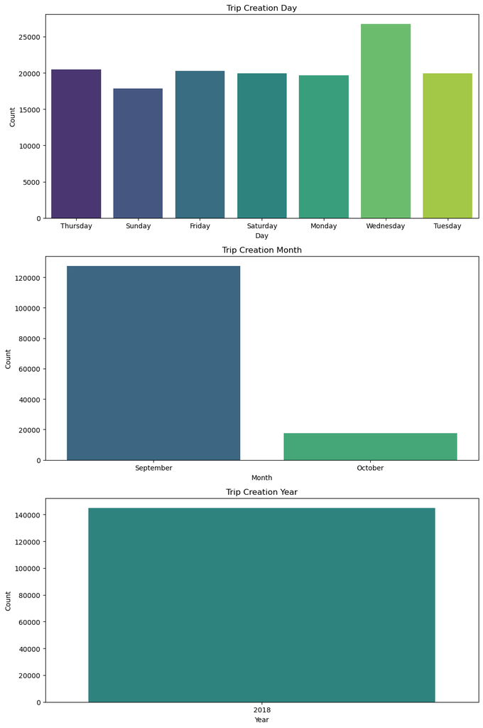

```python
fig, axs = plt.subplots(3, 1, figsize=(10, 15))

# Plot for trip_creation_day
sns.countplot(data=df, x='trip_creation_day', ax=axs[0], palette='viridis')
axs[0].set_title('Trip Creation Day')
axs[0].set_xlabel('Day')
axs[0].set_ylabel('Count')

# Plot for trip_creation_month
sns.countplot(data=df, x='trip_creation_month', ax=axs[1], palette='viridis')
axs[1].set_title('Trip Creation Month')
axs[1].set_xlabel('Month')
axs[1].set_ylabel('Count')

# Plot for trip_creation_year
sns.countplot(data=df, x='trip_creation_year', ax=axs[2], palette='viridis')
axs[2].set_title('Trip Creation Year')
axs[2].set_xlabel('Year')
axs[2].set_ylabel('Count')

plt.tight_layout()
plt.show()
```

```python
df.nunique()
```

```
data                                   2
trip_creation_time                 14817
route_schedule_uuid                 1504
route_type                             2
trip_uuid                          14817
source_center                       1508
source_name                         1498
destination_center                  1481
destination_name                    1468
od_start_time                      26369
od_end_time                        26369
start_scan_to_end_scan              1915
is_cutoff                              2
cutoff_factor                        501
cutoff_timestamp                   93180
actual_distance_to_destination    144515
actual_time                         3182
osrm_time                           1531
osrm_distance                     138046
factor                             45641
segment_actual_time                  747
segment_osrm_time                    214
segment_osrm_distance             113799
segment_factor                      5675
trip_creation_day                      7
trip_creation_month                    2
trip_creation_year                     1
dtype: int64
```

# Observation

- As we can see the we have 14,817 distinct trips from various sources to destinations.
- Additionally, there are a total of 1,504 delivery routes available.

### Different kind of `routes`

```python
df.groupby("trip_uuid")["route_type"].unique().value_counts()
```

```
[Carting]    8908
[FTL]        5909
Name: route_type, dtype: int64
```

```python
routeType_plot= (df.groupby("trip_uuid")["route_type"].unique().reset_index()["route_type"].apply(lambda x:x[0]).value_counts(normalize = True)*100)
```

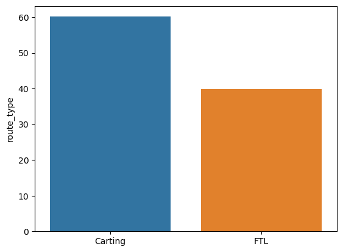

```python
sns.barplot(x= routeType_plot.index,
           y = routeType_plot)
```

# Observation

- Out of `14,817` unique trips, we have:
  - `8,908 (60%)` of the trip routes categorized as `Carting`, involving smaller vehicles, and
  - `5,909 (40%)` of the total trip routes designated as `FTL` (Full Truck Load), which reach their destinations quicker due to the absence of additional pickups or drop-offs en route.

### Feature Engineering

```python
df[df["trip_uuid"]=="trip-153741093647649320"]
```

|  | data | trip_creation_time | route_schedule_uuid | route_type | trip_uuid | source_center | source_name | destination_center | destination_name | od_start_time | ... | osrm_time | osrm_distance | factor | segment_actual_time | segment_osrm_time | segment_osrm_distance | segment_factor | trip_creation_day | trip_creation_month | trip_creation_year |
| --- | --- | --- | --- | --- | --- | --- | --- | --- | --- | --- | --- | --- | --- | --- | --- | --- | --- | --- | --- | --- | --- |
| 0 | training | 2018-09-20 02:35:36.476840 | thanos::sroute:eb7bfc78-b351-4c0e-a951-fa3d5c3... | Carting | trip-153741093647649320 | IND388121AAA | Anand_VUNagar_DC (Gujarat) | IND388620AAB | Khambhat_MotvdDPP_D (Gujarat) | 2018-09-20 03:21:32.418600 | ... | 11.0 | 11.9653 | 1.272727 | 14.0 | 11.0 | 11.9653 | 1.272727 | Thursday | September | 2018 |
| 1 | training | 2018-09-20 02:35:36.476840 | thanos::sroute:eb7bfc78-b351-4c0e-a951-fa3d5c3... | Carting | trip-153741093647649320 | IND388121AAA | Anand_VUNagar_DC (Gujarat) | IND388620AAB | Khambhat_MotvdDPP_D (Gujarat) | 2018-09-20 03:21:32.418600 | ... | 20.0 | 21.7243 | 1.200000 | 10.0 | 9.0 | 9.7590 | 1.111111 | Thursday | September | 2018 |
| 2 | training | 2018-09-20 02:35:36.476840 | thanos::sroute:eb7bfc78-b351-4c0e-a951-fa3d5c3... | Carting | trip-153741093647649320 | IND388121AAA | Anand_VUNagar_DC (Gujarat) | IND388620AAB | Khambhat_MotvdDPP_D (Gujarat) | 2018-09-20 03:21:32.418600 | ... | 28.0 | 32.5395 | 1.428571 | 16.0 | 7.0 | 10.8152 | 2.285714 | Thursday | September | 2018 |
| 3 | training | 2018-09-20 02:35:36.476840 | thanos::sroute:eb7bfc78-b351-4c0e-a951-fa3d5c3... | Carting | trip-153741093647649320 | IND388121AAA | Anand_VUNagar_DC (Gujarat) | IND388620AAB | Khambhat_MotvdDPP_D (Gujarat) | 2018-09-20 03:21:32.418600 | ... | 40.0 | 45.5620 | 1.550000 | 21.0 | 12.0 | 13.0224 | 1.750000 | Thursday | September | 2018 |
| 4 | training | 2018-09-20 02:35:36.476840 | thanos::sroute:eb7bfc78-b351-4c0e-a951-fa3d5c3... | Carting | trip-153741093647649320 | IND388121AAA | Anand_VUNagar_DC (Gujarat) | IND388620AAB | Khambhat_MotvdDPP_D (Gujarat) | 2018-09-20 03:21:32.418600 | ... | 44.0 | 54.2181 | 1.545455 | 6.0 | 5.0 | 3.9153 | 1.200000 | Thursday | September | 2018 |
| 5 | training | 2018-09-20 02:35:36.476840 | thanos::sroute:eb7bfc78-b351-4c0e-a951-fa3d5c3... | Carting | trip-153741093647649320 | IND388620AAB | Khambhat_MotvdDPP_D (Gujarat) | IND388320AAA | Anand_Vaghasi_IP (Gujarat) | 2018-09-20 04:47:45.236797 | ... | 11.0 | 12.1171 | 1.363636 | 15.0 | 11.0 | 12.1171 | 1.363636 | Thursday | September | 2018 |
| 6 | training | 2018-09-20 02:35:36.476840 | thanos::sroute:eb7bfc78-b351-4c0e-a951-fa3d5c3... | Carting | trip-153741093647649320 | IND388620AAB | Khambhat_MotvdDPP_D (Gujarat) | IND388320AAA | Anand_Vaghasi_IP (Gujarat) | 2018-09-20 04:47:45.236797 | ... | 17.0 | 21.2890 | 2.588235 | 28.0 | 6.0 | 9.1719 | 4.666667 | Thursday | September | 2018 |
| 7 | training | 2018-09-20 02:35:36.476840 | thanos::sroute:eb7bfc78-b351-4c0e-a951-fa3d5c3... | Carting | trip-153741093647649320 | IND388620AAB | Khambhat_MotvdDPP_D (Gujarat) | IND388320AAA | Anand_Vaghasi_IP (Gujarat) | 2018-09-20 04:47:45.236797 | ... | 29.0 | 35.8252 | 2.241379 | 21.0 | 11.0 | 14.5362 | 1.909091 | Thursday | September | 2018 |
| 8 | training | 2018-09-20 02:35:36.476840 | thanos::sroute:eb7bfc78-b351-4c0e-a951-fa3d5c3... | Carting | trip-153741093647649320 | IND388620AAB | Khambhat_MotvdDPP_D (Gujarat) | IND388320AAA | Anand_Vaghasi_IP (Gujarat) | 2018-09-20 04:47:45.236797 | ... | 39.0 | 47.1900 | 1.948718 | 10.0 | 10.0 | 11.3648 | 1.000000 | Thursday | September | 2018 |
| 9 | training | 2018-09-20 02:35:36.476840 | thanos::sroute:eb7bfc78-b351-4c0e-a951-fa3d5c3... | Carting | trip-153741093647649320 | IND388620AAB | Khambhat_MotvdDPP_D (Gujarat) | IND388320AAA | Anand_Vaghasi_IP (Gujarat) | 2018-09-20 04:47:45.236797 | ... | 45.0 | 53.2334 | 2.266667 | 26.0 | 6.0 | 6.0434 | 4.333333 | Thursday | September | 2018 |

10 rows × 27 columns

# Observation

In the outlined trip record above, a single trip is divided among various drop-off locations.

We notice that the trip includes stops at specified source and destination centers (warehouses). The terms '**od-end-time**' and '**od-start-time**' represent the respective ending and starting times of this particular trip.

The '**start-scan-to-end-scan**' duration refers to the time span during which trips are scanned at the beginning and the end. The time provided for '**start-scan-to-end-scan**' is cumulative, not detailed per trip segment.

The indicator '**trip cut off False**' documents the instances when a trip transitions from one warehouse to another along the source to destination route.

The '**Actual-time**' provided denotes the cumulative time taken to complete the entire delivery from the source to the destination.

'**OSRM-time**' stems from an open-source routing engine that calculates the shortest route between points on a given map, estimating the required time, while '**osrm distance**' provides the shortest distance, both of which are given cumulatively.

The '**Actual-distance-to-destination**' represents the cumulative distance between warehouses encountered during the trip. Whenever '**trip cut off**' is False, the distance count recommences from the start.

'**Segment actual time**' reflects the real time taken between two stops during the trip, specified for each segment (taken amid a subset of package delivery).

Lastly, '**segment osrm time**' refers to the OSRM estimated time for each segment, calculated between subsets of package deliveries.

```python
df["source_city"] = df["source_name"].str.split(" ",n=1,expand=True)[0].str.split("_",n=1,expand=True)[0]
df["source_state"] = df["source_name"].str.split(" ",n=1,expand=True)[1].str.replace("(","").str.replace(")","")

df["destination_city"] = df["destination_name"].str.split(" ",n=1,expand=True)[0].str.split("_",n=1,expand=True)[0]
df["destination_state"] = df["destination_name"].str.split(" ",n=1,expand=True)[1].str.replace("(","").str.replace(")","")
```

```python
df["source_place"] = df["source_name"].str.split("_",n=2,expand=True)[1]
df["destination_place"] = df["destination_name"].str.split("_",n=2,expand=True)[1]

df["source_pincode"] = df["source_center"].apply(lambda x : x[3:9] )
df["destination_pincode"] = df["destination_center"].apply(lambda x : x[3:9] )
```

```python
df.head()
```

|  | data | trip_creation_time | route_schedule_uuid | route_type | trip_uuid | source_center | source_name | destination_center | destination_name | od_start_time | ... | trip_creation_month | trip_creation_year | source_city | source_state | destination_city | destination_state | source_place | destination_place | source_pincode | destination_pincode |
| --- | --- | --- | --- | --- | --- | --- | --- | --- | --- | --- | --- | --- | --- | --- | --- | --- | --- | --- | --- | --- | --- |
| 0 | training | 2018-09-20 02:35:36.476840 | thanos::sroute:eb7bfc78-b351-4c0e-a951-fa3d5c3... | Carting | trip-153741093647649320 | IND388121AAA | Anand_VUNagar_DC (Gujarat) | IND388620AAB | Khambhat_MotvdDPP_D (Gujarat) | 2018-09-20 03:21:32.418600 | ... | September | 2018 | Anand | Gujarat | Khambhat | Gujarat | VUNagar | MotvdDPP | 388121 | 388620 |
| 1 | training | 2018-09-20 02:35:36.476840 | thanos::sroute:eb7bfc78-b351-4c0e-a951-fa3d5c3... | Carting | trip-153741093647649320 | IND388121AAA | Anand_VUNagar_DC (Gujarat) | IND388620AAB | Khambhat_MotvdDPP_D (Gujarat) | 2018-09-20 03:21:32.418600 | ... | September | 2018 | Anand | Gujarat | Khambhat | Gujarat | VUNagar | MotvdDPP | 388121 | 388620 |
| 2 | training | 2018-09-20 02:35:36.476840 | thanos::sroute:eb7bfc78-b351-4c0e-a951-fa3d5c3... | Carting | trip-153741093647649320 | IND388121AAA | Anand_VUNagar_DC (Gujarat) | IND388620AAB | Khambhat_MotvdDPP_D (Gujarat) | 2018-09-20 03:21:32.418600 | ... | September | 2018 | Anand | Gujarat | Khambhat | Gujarat | VUNagar | MotvdDPP | 388121 | 388620 |
| 3 | training | 2018-09-20 02:35:36.476840 | thanos::sroute:eb7bfc78-b351-4c0e-a951-fa3d5c3... | Carting | trip-153741093647649320 | IND388121AAA | Anand_VUNagar_DC (Gujarat) | IND388620AAB | Khambhat_MotvdDPP_D (Gujarat) | 2018-09-20 03:21:32.418600 | ... | September | 2018 | Anand | Gujarat | Khambhat | Gujarat | VUNagar | MotvdDPP | 388121 | 388620 |
| 4 | training | 2018-09-20 02:35:36.476840 | thanos::sroute:eb7bfc78-b351-4c0e-a951-fa3d5c3... | Carting | trip-153741093647649320 | IND388121AAA | Anand_VUNagar_DC (Gujarat) | IND388620AAB | Khambhat_MotvdDPP_D (Gujarat) | 2018-09-20 03:21:32.418600 | ... | September | 2018 | Anand | Gujarat | Khambhat | Gujarat | VUNagar | MotvdDPP | 388121 | 388620 |

5 rows × 35 columns

```python
df["time_taken_btwn_odstart_and_od_end"] = ((df["od_end_time"]-df["od_start_time"])/pd.Timedelta(1,unit="hour"))
```

### Converting given time duration features into hours

```
start_scan_to_end_scan
actual_time
osrm_time
segment_actual_time
segment_osrm_time
```

```python
df["start_scan_to_end_scan"] = df["start_scan_to_end_scan"]/60
df["actual_time"] = df["actual_time"]/60
df["osrm_time"] = df["osrm_time"]/60
df["segment_actual_time"] = df["segment_actual_time"]/60
df["segment_osrm_time"] = df["segment_osrm_time"]/60
```

```python
df.info()
```

```
<class 'pandas.core.frame.DataFrame'>
RangeIndex: 144867 entries, 0 to 144866
Data columns (total 36 columns):
 #   Column                              Non-Null Count   Dtype
---  ------                              --------------   -----
 0   data                                144867 non-null  object
 1   trip_creation_time                  144867 non-null  datetime64[ns]
 2   route_schedule_uuid                 144867 non-null  object
 3   route_type                          144867 non-null  object
 4   trip_uuid                           144867 non-null  object
 5   source_center                       144867 non-null  object
 6   source_name                         144574 non-null  object
 7   destination_center                  144867 non-null  object
 8   destination_name                    144606 non-null  object
 9   od_start_time                       144867 non-null  datetime64[ns]
```

[output cut: 28 more lines]

```python
df.isna().sum()
```

```
data                                     0
trip_creation_time                       0
route_schedule_uuid                      0
route_type                               0
trip_uuid                                0
source_center                            0
source_name                            293
destination_center                       0
destination_name                       261
od_start_time                            0
od_end_time                              0
start_scan_to_end_scan                   0
is_cutoff                                0
cutoff_factor                            0
cutoff_timestamp                         0
actual_distance_to_destination           0
actual_time                              0
osrm_time                                0
osrm_distance                            0
factor                                   0
segment_actual_time                      0
segment_osrm_time                        0
segment_osrm_distance                    0
segment_factor                           0
trip_creation_day                        0
trip_creation_month                      0
trip_creation_year                       0
source_city                            293
source_state                           293
destination_city                       261
destination_state                      261
source_place                          2400
destination_place                     2702
source_pincode                           0
destination_pincode                      0
time_taken_btwn_odstart_and_od_end       0
dtype: int64
```

### Data `cleaning`

```python
df["source_state"] = df["source_state"].replace({"Goa Goa":"Goa",
                           "Layout PC Karnataka":"Karnataka",
                           "Vadgaon Sheri DPC Maharashtra":"Maharashtra",
                           "Pashan DPC Maharashtra":"Maharashtra",
                           "City Madhya Pradesh":"Madhya Pradesh",
                           "02_DPC Uttar Pradesh":"Uttar Pradesh",
                           "Nagar_DC Rajasthan":"Rajasthan",
                           "Alipore_DPC West Bengal":"West Bengal",
                            "Mandakni Madhya Pradesh":"Madhya Pradesh",
                            "West _Dc Maharashtra":"Maharashtra",
                            "DC Rajasthan":"Rajasthan",
                            "MP Nagar Madhya Pradesh":"Madhya Pradesh",
                            "Antop Hill Maharashtra":"Maharashtra",
                            "Avenue_DPC West Bengal":"West Bengal",
                            "Nagar Uttar Pradesh":"Uttar Pradesh",
                            "Balaji Nagar Maharashtra":"Maharashtra",
                            "Kothanur_L Karnataka":"Karnataka",
                            "Rahatani DPC Maharashtra":"Maharashtra",
                            "Mahim Maharashtra":"Maharashtra",
                            "DC Maharashtra":"Maharashtra",
                            "_NAD Andhra Pradesh":"Andhra Pradesh",
                                                       })

df["destination_state"] = df["destination_state"].replace({"Goa Goa":"Goa",
                           "Layout PC Karnataka":"Karnataka",
                           "Vadgaon Sheri DPC Maharashtra":"Maharashtra",
                           "Pashan DPC Maharashtra":"Maharashtra",
                           "City Madhya Pradesh":"Madhya Pradesh",
                           "02_DPC Uttar Pradesh":"Uttar Pradesh",
                           "Nagar_DC Rajasthan":"Rajasthan",
                           "Alipore_DPC West Bengal":"West Bengal",
                            "Mandakni Madhya Pradesh":"Madhya Pradesh",
                            "West _Dc Maharashtra":"Maharashtra",
                            "DC Rajasthan":"Rajasthan",
                            "MP Nagar Madhya Pradesh":"Madhya Pradesh",
                            "Antop Hill Maharashtra":"Maharashtra",
                            "Avenue_DPC West Bengal":"West Bengal",
                            "Nagar Uttar Pradesh":"Uttar Pradesh",
                            "Balaji Nagar Maharashtra":"Maharashtra",
                            "Kothanur_L Karnataka":"Karnataka",
                            "Rahatani DPC Maharashtra":"Maharashtra",
                            "Mahim Maharashtra":"Maharashtra",
                            "DC Maharashtra":"Maharashtra",
                            "_NAD Andhra Pradesh":"Andhra Pradesh",
                           "Delhi Delhi":"Delhi",
                           "West_Dc Maharashtra":"Maharashtra",
                           "Hub Maharashtra":"Maharashtra"
                                                       })
```

```python
df["destination_city"].replace({
                                    "del":"Delhi"
                                },inplace=True)

df["source_city"].replace({
                            "del":"Delhi"
                        },inplace=True)
```

```python
df["source_city"].replace({
    "Bangalore":"Bengaluru"
        },inplace=True)

df["destination_city"].replace({
    "Bangalore":"Bengaluru"
        },inplace=True)

df["destination_city"].replace({
    "AMD":"Ahmedabad"
        },inplace=True)

df["destination_city"].replace({
    "Amdavad":"Ahmedabad"
        },inplace=True)

df["source_city"].replace({
    "AMD":"Ahmedabad"
        },inplace=True)

df["source_city"].replace({
    "Amdavad":"Ahmedabad"
        },inplace=True)
```

```python
df["source_city_state"] = df["source_city"] + " " + df["source_state"]
df["destination_city_state"] = df["destination_city"] + " " + df["destination_state"]
```

```python
df["source_city_state"].nunique()
```

```
1249
```

```python
df["destination_city_state"].nunique()
```

```
1242
```

```python
df["source_state"].nunique()
```

```
33
```

```python
df["destination_state"].nunique()
```

```
32
```

```python
data = df.copy()
data.columns
```

```
Index(['data', 'trip_creation_time', 'route_schedule_uuid', 'route_type',
       'trip_uuid', 'source_center', 'source_name', 'destination_center',
       'destination_name', 'od_start_time', 'od_end_time',
       'start_scan_to_end_scan', 'is_cutoff', 'cutoff_factor',
       'cutoff_timestamp', 'actual_distance_to_destination', 'actual_time',
       'osrm_time', 'osrm_distance', 'factor', 'segment_actual_time',
       'segment_osrm_time', 'segment_osrm_distance', 'segment_factor',
       'trip_creation_day', 'trip_creation_month', 'trip_creation_year',
       'source_city', 'source_state', 'destination_city', 'destination_state',
       'source_place', 'destination_place', 'source_pincode',
       'destination_pincode', 'time_taken_btwn_odstart_and_od_end',
       'source_city_state', 'destination_city_state'],
      dtype='object')
```

```python
data.drop(['source_center',"source_name","destination_center","destination_name","cutoff_timestamp"],axis = 1,inplace=True)
```

```python
data.drop(["od_end_time","od_start_time"],axis = 1 , inplace=True)
```

### Aggregation of Data

```python
actual_time = data.groupby(["trip_uuid",
              "start_scan_to_end_scan"])["actual_time"].max().reset_index().groupby("trip_uuid")["actual_time"].sum().reset_index()

segment_osrm_time = data[["trip_uuid","segment_osrm_time"]].groupby("trip_uuid")["segment_osrm_time"].sum().reset_index()

segment_actual_time = data.groupby("trip_uuid")["segment_actual_time"].sum().reset_index()

osrm_time = data.groupby(["trip_uuid",
              "start_scan_to_end_scan"])["osrm_time"].max().reset_index().groupby("trip_uuid")["osrm_time"].sum().reset_index()

time_taken_btwn_odstart_and_od_end = data.groupby("trip_uuid")["time_taken_btwn_odstart_and_od_end"].unique().reset_index()

time_taken_btwn_odstart_and_od_end["time_taken_btwn_odstart_and_od_end"] = time_taken_btwn_odstart_and_od_end["time_taken_btwn_odstart_and_od_end"].apply(sum)

start_scan_to_end_scan = ((data.groupby("trip_uuid")["start_scan_to_end_scan"].unique())).reset_index()

start_scan_to_end_scan["start_scan_to_end_scan"] = start_scan_to_end_scan["start_scan_to_end_scan"].apply(sum)

osrm_distance = data.groupby(["trip_uuid",
              "start_scan_to_end_scan"])["osrm_distance"].max().reset_index().groupby("trip_uuid")["osrm_distance"].sum().reset_index()

actual_distance_to_destination = data.groupby(["trip_uuid",
              "start_scan_to_end_scan"])["actual_distance_to_destination"].max().reset_index().groupby("trip_uuid")["actual_distance_to_destination"].sum().reset_index()

segment_osrm_distance = data[["trip_uuid",
                              "segment_osrm_distance"]].groupby("trip_uuid")["segment_osrm_distance"].sum().reset_index()
```

### Hypothesis Tests for `time durations` and `distance related features`

#### Analysing TimeTaken Between OdStart and OdEnd time & StartScanToEndScan :

- `H0`: Mean of time taken betweenn trip end ans start time = Mean of start and end scan time
- `Ha`: Mean of time taken betweenn trip end ans start time != Mean of start and end scan time

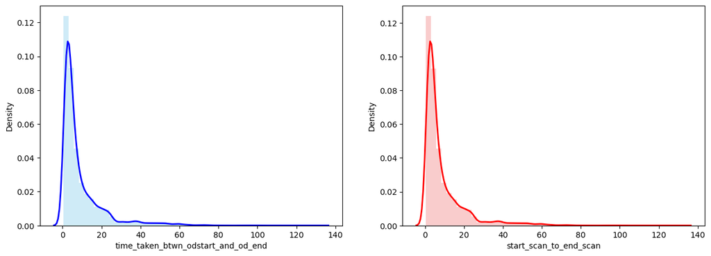

```python
plt.figure(figsize=(15,5))
plt.subplot(121)
sns.distplot(time_taken_btwn_odstart_and_od_end["time_taken_btwn_odstart_and_od_end"], color='skyblue', kde_kws={"color": "blue", "lw": 2})

plt.subplot(122)
sns.distplot(start_scan_to_end_scan["start_scan_to_end_scan"], color='lightcoral', kde_kws={"color": "red", "lw": 2})

plt.show()
```

```python
stats.ks_2samp(time_taken_btwn_odstart_and_od_end["time_taken_btwn_odstart_and_od_end"]
               ,start_scan_to_end_scan["start_scan_to_end_scan"])
```

```
KstestResult(statistic=0.004184382803536474, pvalue=0.9994337058695081, statistic_location=2.466666666666667, statistic_sign=-1)
```

```python
for i in range(5):
    print(stats.ttest_ind((time_taken_btwn_odstart_and_od_end["time_taken_btwn_odstart_and_od_end"].sample(3000))
                ,(start_scan_to_end_scan["start_scan_to_end_scan"].sample(3000))))
```

```
Ttest_indResult(statistic=0.6326948623666184, pvalue=0.5269570441495796)
Ttest_indResult(statistic=-0.15628740861386078, pvalue=0.8758117405992905)
Ttest_indResult(statistic=1.3042366951411266, pvalue=0.1922029376420475)
Ttest_indResult(statistic=1.3966728466442648, pvalue=0.1625636489588813)
Ttest_indResult(statistic=0.030600840779704024, pvalue=0.975588889744748)
```

### Hypothesis Tests for `actual_time` and `start_scan_to_end_scan`

- `H0`: Mean of start and end scan time <= Mean of Actual time taken to complete delivery
- `Ha`: Mean of start and end scan time > Mean of Actual time taken to complete delivery

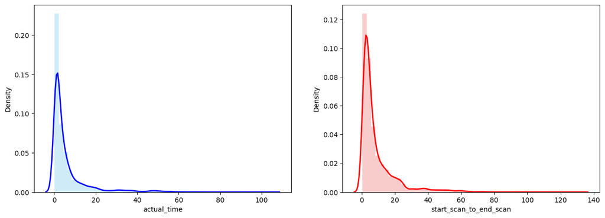

```python
plt.figure(figsize=(15,5))
plt.subplot(121)
sns.distplot(actual_time["actual_time"], color='skyblue', kde_kws={"color": "blue", "lw": 2})

plt.subplot(122)
sns.distplot(start_scan_to_end_scan["start_scan_to_end_scan"], color='lightcoral', kde_kws={"color": "red", "lw": 2})


plt.show()
```

### Merging All the numerical Fields as per `TripID`

```
actual_distance_to_destination
osrm_distance
segment_osrm_distance
time_taken_btwn_odstart_and_od_end
start_scan_to_end_scan
actual_time
segment_actual_time
osrm_time
segment_osrm_time
```

```python
distances = segment_osrm_distance.merge(actual_distance_to_destination.merge(osrm_distance,
                                                                             on="trip_uuid"),
                                                                             on="trip_uuid")

time = segment_osrm_time.merge(osrm_time.merge(segment_actual_time.merge(actual_time.merge(time_taken_btwn_odstart_and_od_end.merge(start_scan_to_end_scan,
                                         on="trip_uuid",
                                         ),on="trip_uuid"),on="trip_uuid"),on="trip_uuid"),on="trip_uuid")

Merge1 = time.merge(distances,on="trip_uuid")
```

```python
Merge1
```

|  | trip_uuid | segment_osrm_time | osrm_time | segment_actual_time | actual_time | time_taken_btwn_odstart_and_od_end | start_scan_to_end_scan | segment_osrm_distance | actual_distance_to_destination | osrm_distance |
| --- | --- | --- | --- | --- | --- | --- | --- | --- | --- | --- |
| 0 | trip-153671041653548748 | 16.800000 | 12.383333 | 25.800000 | 26.033333 | 37.668497 | 37.650000 | 1320.4733 | 824.732854 | 991.3523 |
| 1 | trip-153671042288605164 | 1.083333 | 1.133333 | 2.350000 | 2.383333 | 3.026865 | 3.000000 | 84.1894 | 73.186911 | 85.1110 |
| 2 | trip-153671043369099517 | 32.350000 | 29.016667 | 55.133333 | 55.783333 | 65.572709 | 65.550000 | 2545.2678 | 1932.273969 | 2372.0852 |
| 3 | trip-153671046011330457 | 0.266667 | 0.250000 | 0.983333 | 0.983333 | 1.674916 | 1.666667 | 19.8766 | 17.175274 | 19.6800 |
| 4 | trip-153671052974046625 | 1.916667 | 1.950000 | 5.666667 | 5.683333 | 11.972484 | 11.950000 | 146.7919 | 127.448500 | 146.7918 |
| ... | ... | ... | ... | ... | ... | ... | ... | ... | ... | ... |
| 14812 | trip-153861095625827784 | 1.033333 | 1.033333 | 1.366667 | 1.383333 | 4.300482 | 4.283333 | 64.8551 | 57.762332 | 73.4630 |
| 14813 | trip-153861104386292051 | 0.183333 | 0.200000 | 0.350000 | 0.350000 | 1.009842 | 1.000000 | 16.0883 | 15.513784 | 16.0882 |
| 14814 | trip-153861106442901555 | 1.466667 | 0.900000 | 4.683333 | 4.700000 | 7.035331 | 7.016667 | 104.8866 | 38.684839 | 63.2841 |
| 14815 | trip-153861115439069069 | 3.683333 | 3.066667 | 4.300000 | 4.400000 | 5.808548 | 5.783333 | 223.5324 | 134.723836 | 177.6635 |
| 14816 | trip-153861118270144424 | 1.116667 | 1.133333 | 4.566667 | 4.583333 | 5.906793 | 5.883333 | 80.5787 | 66.081533 | 80.5787 |

14817 rows × 10 columns

### Merging `Location details` and `route_type` and Numerical data on `TripID`

```python
city = data.groupby("trip_uuid")[["source_city",
                                  "destination_city"]].aggregate({
        "source_city":pd.unique,
    "destination_city":pd.unique,
})

state = data.groupby("trip_uuid")[["source_state",
                                   "destination_state"]].aggregate({
        "source_state":pd.unique,
    "destination_state":pd.unique,
})

city_state = data.groupby("trip_uuid")[["source_city_state",
                                        "destination_city_state"]].aggregate({
        "source_city_state":pd.unique,
    "destination_city_state":pd.unique,
})

locations = city.merge(city_state.merge(state,on="trip_uuid"
                            ,how="outer"),
           on="trip_uuid",
           how="outer")
```

```python
route_type = data.groupby("trip_uuid")["route_type"].unique().reset_index()

Merged = route_type.merge(locations.merge(Merge1,on="trip_uuid",
           how="outer"),
                 on="trip_uuid",
           how="outer"
                )
```

```python
trip_records = Merged.copy()
trip_records["route_type"] = trip_records["route_type"].apply(lambda x:x[0])
route_to_merge = data.groupby("trip_uuid")["route_schedule_uuid"].unique().reset_index()
trip_records = trip_records.merge(route_to_merge,on="trip_uuid",how="outer")
trip_records["route_schedule_uuid"] = trip_records["route_schedule_uuid"].apply(lambda x:x[0])
```

```python
trip_records
```

|  | trip_uuid | route_type | source_city | destination_city | source_city_state | destination_city_state | source_state | destination_state | segment_osrm_time | osrm_time | segment_actual_time | actual_time | time_taken_btwn_odstart_and_od_end | start_scan_to_end_scan | segment_osrm_distance | actual_distance_to_destination | osrm_distance | route_schedule_uuid |
| --- | --- | --- | --- | --- | --- | --- | --- | --- | --- | --- | --- | --- | --- | --- | --- | --- | --- | --- |
| 0 | trip-153671041653548748 | FTL | [Bhopal, Kanpur] | [Kanpur, Gurgaon] | [Bhopal Madhya Pradesh, Kanpur Uttar Pradesh] | [Kanpur Uttar Pradesh, Gurgaon Haryana] | [Madhya Pradesh, Uttar Pradesh] | [Uttar Pradesh, Haryana] | 16.800000 | 12.383333 | 25.800000 | 26.033333 | 37.668497 | 37.650000 | 1320.4733 | 824.732854 | 991.3523 | thanos::sroute:d7c989ba-a29b-4a0b-b2f4-288cdc6... |
| 1 | trip-153671042288605164 | Carting | [Tumkur, Doddablpur] | [Doddablpur, Chikblapur] | [Tumkur Karnataka, Doddablpur Karnataka] | [Doddablpur Karnataka, Chikblapur Karnataka] | [Karnataka] | [Karnataka] | 1.083333 | 1.133333 | 2.350000 | 2.383333 | 3.026865 | 3.000000 | 84.1894 | 73.186911 | 85.1110 | thanos::sroute:3a1b0ab2-bb0b-4c53-8c59-eb2a2c0... |
| 2 | trip-153671043369099517 | FTL | [Bengaluru, Gurgaon] | [Gurgaon, Chandigarh] | [Bengaluru Karnataka, Gurgaon Haryana] | [Gurgaon Haryana, Chandigarh Punjab] | [Karnataka, Haryana] | [Haryana, Punjab] | 32.350000 | 29.016667 | 55.133333 | 55.783333 | 65.572709 | 65.550000 | 2545.2678 | 1932.273969 | 2372.0852 | thanos::sroute:de5e208e-7641-45e6-8100-4d9fb1e... |
| 3 | trip-153671046011330457 | Carting | [Mumbai] | [Mumbai] | [Mumbai Hub Maharashtra] | [Mumbai Maharashtra] | [Hub Maharashtra] | [Maharashtra] | 0.266667 | 0.250000 | 0.983333 | 0.983333 | 1.674916 | 1.666667 | 19.8766 | 17.175274 | 19.6800 | thanos::sroute:f0176492-a679-4597-8332-bbd1c7f... |
| 4 | trip-153671052974046625 | FTL | [Bellary, Hospet, Sandur] | [Hospet, Sandur, Bellary] | [Bellary Karnataka, Hospet Karnataka, Sandur K... | [Hospet Karnataka, Sandur Karnataka, Bellary K... | [Karnataka] | [Karnataka] | 1.916667 | 1.950000 | 5.666667 | 5.683333 | 11.972484 | 11.950000 | 146.7919 | 127.448500 | 146.7918 | thanos::sroute:d9f07b12-65e0-4f3b-bec8-df06134... |
| ... | ... | ... | ... | ... | ... | ... | ... | ... | ... | ... | ... | ... | ... | ... | ... | ... | ... | ... |
| 14812 | trip-153861095625827784 | Carting | [Chandigarh] | [Zirakpur, Chandigarh] | [Chandigarh Punjab, Chandigarh Chandigarh] | [Zirakpur Punjab, Chandigarh Punjab] | [Punjab, Chandigarh] | [Punjab] | 1.033333 | 1.033333 | 1.366667 | 1.383333 | 4.300482 | 4.283333 | 64.8551 | 57.762332 | 73.4630 | thanos::sroute:8a120994-f577-4491-9e4b-b7e4a14... |
| 14813 | trip-153861104386292051 | Carting | [FBD] | [Faridabad] | [FBD Haryana] | [Faridabad Haryana] | [Haryana] | [Haryana] | 0.183333 | 0.200000 | 0.350000 | 0.350000 | 1.009842 | 1.000000 | 16.0883 | 15.513784 | 16.0882 | thanos::sroute:b30e1ec3-3bfa-4bd2-a7fb-3b75769... |
| 14814 | trip-153861106442901555 | Carting | [Kanpur] | [Kanpur] | [Kanpur Uttar Pradesh] | [Kanpur Uttar Pradesh] | [Uttar Pradesh] | [Uttar Pradesh] | 1.466667 | 0.900000 | 4.683333 | 4.700000 | 7.035331 | 7.016667 | 104.8866 | 38.684839 | 63.2841 | thanos::sroute:5609c268-e436-4e0a-8180-3db4a74... |
| 14815 | trip-153861115439069069 | Carting | [Tirunelveli, Eral, Tirchchndr, Thisayanvilai,... | [Eral, Tirchchndr, Thisayanvilai, Peikulam, Ti... | [Tirunelveli Tamil Nadu, Eral Tamil Nadu, Tirc... | [Eral Tamil Nadu, Tirchchndr Tamil Nadu, Thisa... | [Tamil Nadu] | [Tamil Nadu] | 3.683333 | 3.066667 | 4.300000 | 4.400000 | 5.808548 | 5.783333 | 223.5324 | 134.723836 | 177.6635 | thanos::sroute:c5f2ba2c-8486-4940-8af6-d1d2a6a... |
| 14816 | trip-153861118270144424 | FTL | [Hospet, Sandur] | [Sandur, Bellary] | [Hospet Karnataka, Sandur Karnataka] | [Sandur Karnataka, Bellary Karnataka] | [Karnataka] | [Karnataka] | 1.116667 | 1.133333 | 4.566667 | 4.583333 | 5.906793 | 5.883333 | 80.5787 | 66.081533 | 80.5787 | thanos::sroute:412fea14-6d1f-4222-8a5f-a517042... |

14817 rows × 18 columns

```python
trip_records.isna().sum()
```

```
trip_uuid                             0
route_type                            0
source_city                           0
destination_city                      0
source_city_state                     0
destination_city_state                0
source_state                          0
destination_state                     0
segment_osrm_time                     0
osrm_time                             0
segment_actual_time                   0
actual_time                           0
time_taken_btwn_odstart_and_od_end    0
start_scan_to_end_scan                0
segment_osrm_distance                 0
actual_distance_to_destination        0
osrm_distance                         0
route_schedule_uuid                   0
dtype: int64
```

```python
trip_records["source_city"] = trip_records["source_city"].astype("str").str.strip("[]").str.replace("'","")
trip_records["destination_city"] = trip_records["destination_city"].astype("str").str.strip("[]").str.replace("'","")
trip_records["source_city_state"] = trip_records["source_city_state"].astype("str").str.strip("[]").str.replace("'","")
trip_records["destination_city_state"] = trip_records["destination_city_state"].astype("str").str.strip("[]").str.replace("'","")

trip_records["source_state"] = trip_records["source_state"].astype("str").str.strip("[]").str.replace("'","")
trip_records["destination_state"] = trip_records["destination_state"].astype("str").str.strip("[]").str.replace("'","")
```

```python
trip_records.isna().sum()
```

```
trip_uuid                             0
route_type                            0
source_city                           0
destination_city                      0
source_city_state                     0
destination_city_state                0
source_state                          0
destination_state                     0
segment_osrm_time                     0
osrm_time                             0
segment_actual_time                   0
actual_time                           0
time_taken_btwn_odstart_and_od_end    0
start_scan_to_end_scan                0
segment_osrm_distance                 0
actual_distance_to_destination        0
osrm_distance                         0
route_schedule_uuid                   0
dtype: int64
```

### Finding `Outliers`

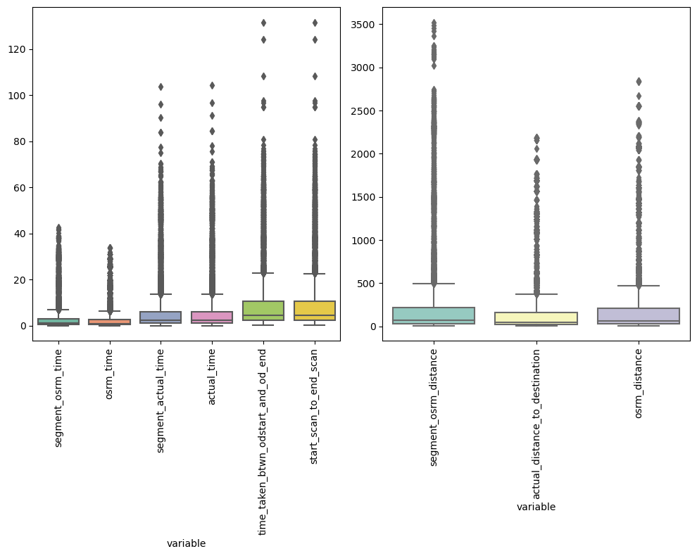

```python
plt.figure(figsize=(10, 8))

# Melt your data frames to long-form
long_form_1 = trip_records[['segment_osrm_time', 'osrm_time', 'segment_actual_time', 'actual_time', 'time_taken_btwn_odstart_and_od_end', 'start_scan_to_end_scan']].melt()
long_form_2 = trip_records[['segment_osrm_distance', 'actual_distance_to_destination', 'osrm_distance']].melt()

# Plotting boxplot for the first set of columns
plt.subplot(121)
sns.boxplot(x='variable', y='value', data=long_form_1, palette='Set2')
plt.xticks(rotation=90)
plt.ylabel('')

# Plotting boxplot for the second set of columns
plt.subplot(122)
sns.boxplot(x='variable', y='value', data=long_form_2, palette='Set3')
plt.xticks(rotation=90)
plt.ylabel('')

plt.tight_layout()
plt.show()
```

```python
outlier_treatment  = trip_records.copy()

outlier_treatment_num = outlier_treatment[['segment_osrm_time', 'osrm_time',
       'segment_actual_time', 'actual_time',
       'time_taken_btwn_odstart_and_od_end', 'start_scan_to_end_scan',
        'segment_osrm_distance', 'actual_distance_to_destination',
        'osrm_distance']]
```

### Removing all the outliers from all numerical features

```python
trip_records_without_outliers = trip_records.loc[outlier_treatment_num[(np.abs(stats.zscore(outlier_treatment_num)) < 3).all(axis=1)].index]
trip_records_without_outliers.head()
```

|  | trip_uuid | route_type | source_city | destination_city | source_city_state | destination_city_state | source_state | destination_state | segment_osrm_time | osrm_time | segment_actual_time | actual_time | time_taken_btwn_odstart_and_od_end | start_scan_to_end_scan | segment_osrm_distance | actual_distance_to_destination | osrm_distance | route_schedule_uuid |
| --- | --- | --- | --- | --- | --- | --- | --- | --- | --- | --- | --- | --- | --- | --- | --- | --- | --- | --- |
| 0 | trip-153671041653548748 | FTL | Bhopal Kanpur | Kanpur Gurgaon | Bhopal Madhya Pradesh Kanpur Uttar Pradesh | Kanpur Uttar Pradesh Gurgaon Haryana | Madhya Pradesh Uttar Pradesh | Uttar Pradesh Haryana | 16.800000 | 12.383333 | 25.800000 | 26.033333 | 37.668497 | 37.650000 | 1320.4733 | 824.732854 | 991.3523 | thanos::sroute:d7c989ba-a29b-4a0b-b2f4-288cdc6... |
| 1 | trip-153671042288605164 | Carting | Tumkur Doddablpur | Doddablpur Chikblapur | Tumkur Karnataka Doddablpur Karnataka | Doddablpur Karnataka Chikblapur Karnataka | Karnataka | Karnataka | 1.083333 | 1.133333 | 2.350000 | 2.383333 | 3.026865 | 3.000000 | 84.1894 | 73.186911 | 85.1110 | thanos::sroute:3a1b0ab2-bb0b-4c53-8c59-eb2a2c0... |
| 3 | trip-153671046011330457 | Carting | Mumbai | Mumbai | Mumbai Hub Maharashtra | Mumbai Maharashtra | Hub Maharashtra | Maharashtra | 0.266667 | 0.250000 | 0.983333 | 0.983333 | 1.674916 | 1.666667 | 19.8766 | 17.175274 | 19.6800 | thanos::sroute:f0176492-a679-4597-8332-bbd1c7f... |
| 4 | trip-153671052974046625 | FTL | Bellary Hospet Sandur | Hospet Sandur Bellary | Bellary Karnataka Hospet Karnataka Sandur Karn... | Hospet Karnataka Sandur Karnataka Bellary Karn... | Karnataka | Karnataka | 1.916667 | 1.950000 | 5.666667 | 5.683333 | 11.972484 | 11.950000 | 146.7919 | 127.448500 | 146.7918 | thanos::sroute:d9f07b12-65e0-4f3b-bec8-df06134... |
| 5 | trip-153671055416136166 | Carting | Chennai | Chennai | Chennai Tamil Nadu | Chennai Tamil Nadu | Tamil Nadu | Tamil Nadu | 0.383333 | 0.383333 | 1.000000 | 1.016667 | 3.174797 | 3.150000 | 28.0647 | 24.597048 | 28.0647 | thanos::sroute:9bf03170-d0a2-4a3f-aa4d-9aaab3d... |

```python
trip_records_without_outliers = trip_records_without_outliers[['trip_uuid','route_type','source_city_state', 'destination_city_state','segment_osrm_time', 'osrm_time',
       'segment_actual_time', 'actual_time',
       'time_taken_btwn_odstart_and_od_end', 'start_scan_to_end_scan',
       'segment_osrm_distance', 'actual_distance_to_destination',
       'osrm_distance']]
```

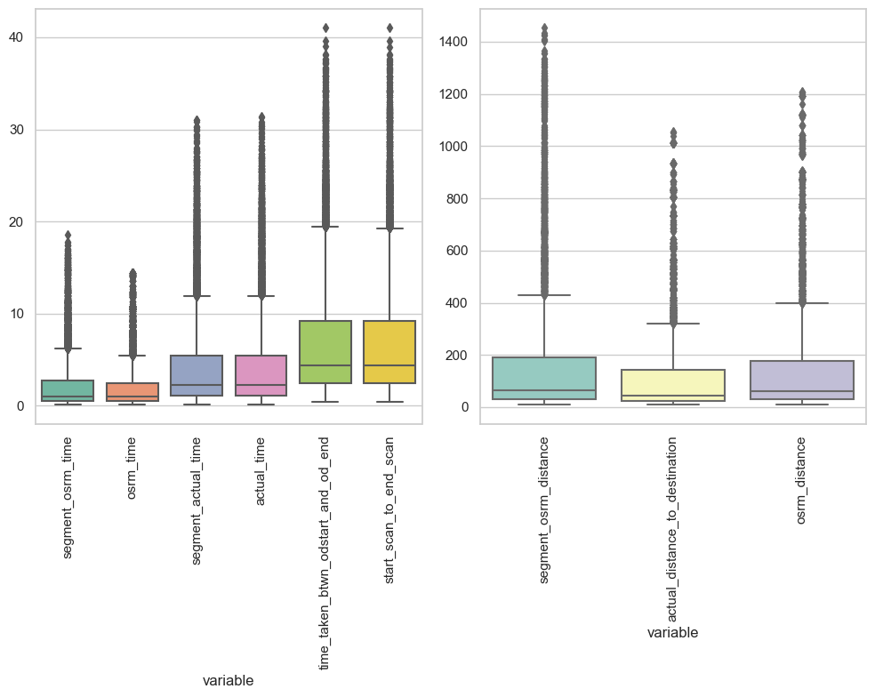

```python
sns.set(style="whitegrid")

plt.figure(figsize=(10,8))

# Melt DataFrames to long-form
long_form_1 = trip_records_without_outliers[['segment_osrm_time', 'osrm_time', 'segment_actual_time', 'actual_time', 'time_taken_btwn_odstart_and_od_end', 'start_scan_to_end_scan']].melt()
long_form_2 = trip_records_without_outliers[['segment_osrm_distance', 'actual_distance_to_destination', 'osrm_distance']].melt()

# Plotting boxplot for the first set of columns
plt.subplot(121)
sns.boxplot(x='variable', y='value', data=long_form_1, palette='Set2')
plt.xticks(rotation=90)
plt.ylabel('')

# Plotting boxplot for the second set of columns
plt.subplot(122)
sns.boxplot(x='variable', y='value', data=long_form_2, palette='Set3')
plt.xticks(rotation=90)
plt.ylabel('')

plt.tight_layout()  # Adjusts the spacing
plt.show()
```

### Processing Data with `One Hot Encoding`

```python
trip_records_without_outliers["destination_source_locations"] = trip_records_without_outliers["source_city_state"]+" "+trip_records_without_outliers["destination_city_state"]
trip_records_without_outliers.drop(["source_city_state","destination_city_state"],axis = 1,inplace=True)
```

```python
sc_dc = trip_records_without_outliers.groupby(["destination_source_locations"])["trip_uuid"].nunique().sort_values(ascending= False).reset_index()
```

```python
def get_cat(H):
    if 0 <= H <= 50:
        return "Category 7"
    elif 51 <= H <= 100:
        return "Category 6"
    elif 101 <= H <= 200:
        return "Category 5"
    elif 201 <= H <= 300:
        return "Category 4"
    elif 301 <= H <= 400:
        return "Category 3"
    elif 401 <= H <= 500:
        return "Category 2"
    else:
        return "Category 1"
```

```python
sc_dc["city"]  = pd.Series(map(get_cat,sc_dc["trip_uuid"]))

trip_records_for_encoding = sc_dc.merge(trip_records_without_outliers,
            on="destination_source_locations")

trip_records_for_encoding.drop(["destination_source_locations","trip_uuid_x"],axis = 1,inplace=True)

trip_records_for_encoding.drop(["trip_uuid_y"],axis = 1,inplace=True)

encoded_data = pd.get_dummies(trip_records_for_encoding,
             columns=["route_type","city"] )
```

```python
encoded_data.head()
```

|  | segment_osrm_time | osrm_time | segment_actual_time | actual_time | time_taken_btwn_odstart_and_od_end | start_scan_to_end_scan | segment_osrm_distance | actual_distance_to_destination | osrm_distance | route_type_Carting | route_type_FTL | city_Category 1 | city_Category 2 | city_Category 3 | city_Category 4 | city_Category 5 | city_Category 6 | city_Category 7 |
| --- | --- | --- | --- | --- | --- | --- | --- | --- | --- | --- | --- | --- | --- | --- | --- | --- | --- | --- |
| 0 | 1.383333 | 0.950000 | 3.183333 | 3.233333 | 4.407028 | 4.400000 | 76.1272 | 42.240305 | 53.1902 | 1 | 0 | 1 | 0 | 0 | 0 | 0 | 0 | 0 |
| 1 | 1.150000 | 0.883333 | 2.666667 | 2.700000 | 4.063014 | 4.050000 | 59.1472 | 28.706240 | 43.5805 | 1 | 0 | 1 | 0 | 0 | 0 | 0 | 0 | 0 |
| 2 | 1.183333 | 0.966667 | 3.316667 | 3.333333 | 4.076829 | 4.066667 | 65.6004 | 42.150597 | 62.8568 | 1 | 0 | 1 | 0 | 0 | 0 | 0 | 0 | 0 |
| 3 | 0.700000 | 0.733333 | 1.316667 | 1.316667 | 4.915934 | 4.900000 | 41.8593 | 32.569779 | 42.0797 | 1 | 0 | 1 | 0 | 0 | 0 | 0 | 0 | 0 |
| 4 | 0.783333 | 0.666667 | 1.750000 | 1.766667 | 3.248617 | 3.233333 | 39.3452 | 29.584603 | 35.5419 | 1 | 0 | 1 | 0 | 0 | 0 | 0 | 0 | 0 |

```python
from sklearn.preprocessing import StandardScaler
from sklearn.preprocessing import MinMaxScaler
```

```python
scaler = StandardScaler()
std_data = scaler.fit_transform(encoded_data[['segment_osrm_time',
                                                 'osrm_time',
                                                 'segment_actual_time',
                                                 'actual_time',
                                                 'time_taken_btwn_odstart_and_od_end',
                                                 'start_scan_to_end_scan',
                                                 'segment_osrm_distance',
                                                 'actual_distance_to_destination',
                                                 'osrm_distance']])
std_data = pd.DataFrame(std_data, columns=['segment_osrm_time',
                                             'osrm_time',
                                             'segment_actual_time',
                                             'actual_time',
                                             'time_taken_btwn_odstart_and_od_end',
                                             'start_scan_to_end_scan',
                                             'segment_osrm_distance',
                                             'actual_distance_to_destination',
                                             'osrm_distance'])

std_data.head()
```

|  | segment_osrm_time | osrm_time | segment_actual_time | actual_time | time_taken_btwn_odstart_and_od_end | start_scan_to_end_scan | segment_osrm_distance | actual_distance_to_destination | osrm_distance |
| --- | --- | --- | --- | --- | --- | --- | --- | --- | --- |
| 0 | -0.269133 | -0.409683 | -0.220225 | -0.214843 | -0.394178 | -0.391956 | -0.362747 | -0.450888 | -0.468190 |
| 1 | -0.359785 | -0.438916 | -0.324535 | -0.321822 | -0.445632 | -0.444397 | -0.448864 | -0.542288 | -0.521446 |
| 2 | -0.346835 | -0.402374 | -0.193306 | -0.194785 | -0.443566 | -0.441900 | -0.416136 | -0.451494 | -0.414618 |
| 3 | -0.534615 | -0.504692 | -0.597087 | -0.599297 | -0.318061 | -0.317039 | -0.536543 | -0.516196 | -0.529763 |
| 4 | -0.502239 | -0.533926 | -0.509601 | -0.509034 | -0.567441 | -0.566761 | -0.549293 | -0.536356 | -0.565995 |

```python
scaler = MinMaxScaler()

MinMax_data = scaler.fit_transform(encoded_data[['segment_osrm_time','osrm_time','segment_actual_time','actual_time',
 'time_taken_btwn_odstart_and_od_end','start_scan_to_end_scan','segment_osrm_distance','actual_distance_to_destination',
 'osrm_distance']])

MinMax_data = pd.DataFrame(MinMax_data,columns=['segment_osrm_time',
 'osrm_time','segment_actual_time','actual_time','time_taken_btwn_odstart_and_od_end','start_scan_to_end_scan',
 'segment_osrm_distance','actual_distance_to_destination','osrm_distance'])

MinMax_data.head()
```

|  | segment_osrm_time | osrm_time | segment_actual_time | actual_time | time_taken_btwn_odstart_and_od_end | start_scan_to_end_scan | segment_osrm_distance | actual_distance_to_destination | osrm_distance |
| --- | --- | --- | --- | --- | --- | --- | --- | --- | --- |
| 0 | 0.069369 | 0.059302 | 0.098113 | 0.098719 | 0.098792 | 0.098811 | 0.046420 | 0.031804 | 0.036747 |
| 1 | 0.056757 | 0.054651 | 0.081402 | 0.081644 | 0.090329 | 0.090201 | 0.034665 | 0.018854 | 0.028743 |
| 2 | 0.058559 | 0.060465 | 0.102426 | 0.101921 | 0.090669 | 0.090611 | 0.039132 | 0.031718 | 0.044799 |
| 3 | 0.032432 | 0.044186 | 0.037736 | 0.037353 | 0.111311 | 0.111111 | 0.022697 | 0.022551 | 0.027493 |
| 4 | 0.036937 | 0.039535 | 0.051752 | 0.051761 | 0.070296 | 0.070111 | 0.020957 | 0.019694 | 0.022047 |

```python
one_hot_encoded_data = encoded_data[["route_type_Carting","route_type_FTL","city_Category 1",
                                     "city_Category 2","city_Category 3","city_Category 4",
                                     "city_Category 5","city_Category 6","city_Category 7"]]
```

### Route Analysis

```python
A = data.groupby("route_schedule_uuid")["route_type"].unique().reset_index()

B = data.groupby("route_schedule_uuid")["destination_city"].unique().reset_index()
B.columns = ["route_schedule_uuid","destination_cities"]

C = data.groupby("route_schedule_uuid")["source_city"].unique().reset_index()
C.columns = ["route_schedule_uuid","source_cities"]

D = data.groupby("route_schedule_uuid")["source_state"].unique().reset_index()
D.columns = ["route_schedule_uuid","source_states"]

E = data.groupby("route_schedule_uuid")["destination_state"].unique().reset_index()
E.columns = ["route_schedule_uuid","destination_states"]

F = data.groupby("route_schedule_uuid")[["source_state",
                                         "destination_state"]].nunique().sort_values(by="source_state",
                                                                                     ascending=False).reset_index()
F.columns = ["route_schedule_uuid","#source_states"
             ,"#destination_states"]

G = trip_records.groupby("route_schedule_uuid")["actual_distance_to_destination"].mean().reset_index()
G.columns = ["route_schedule_uuid","Average_Actual_distance_to_destination"]

H = trip_records["route_schedule_uuid"].value_counts().reset_index()
H.columns = ["route_schedule_uuid","Number_of_Trips"]
```

```python
I = data.groupby("route_schedule_uuid")[["source_city",
                                         "destination_city"]].nunique().sort_values(by="source_city",
                                                                                     ascending=False).reset_index()
I.columns = ["route_schedule_uuid","#source_cities"
             ,"#destination_cities"]
```

```python
route_records = I.merge(H.merge(G.merge(F.merge(E.merge(D.merge(C.merge(A.merge(B,
        on ="route_schedule_uuid",
        how = "outer"),on ="route_schedule_uuid",
        how = "outer"),
       on ="route_schedule_uuid",
        how = "outer"),
       on ="route_schedule_uuid",
        how = "outer"),
       on ="route_schedule_uuid",
        how = "outer"),
       on ="route_schedule_uuid",
        how = "outer"),
       on ="route_schedule_uuid",
        how = "outer"),on ="route_schedule_uuid",
        how = "outer")
```

```python
route_records.isna().sum()
```

```
route_schedule_uuid                       0
#source_cities                            0
#destination_cities                       0
Number_of_Trips                           0
Average_Actual_distance_to_destination    0
#source_states                            0
#destination_states                       0
destination_states                        0
source_states                             0
source_cities                             0
route_type                                0
destination_cities                        0
dtype: int64
```

```python
route_records["route_type"] = route_records["route_type"].astype("str").str.strip("[]").str.replace("'","")
route_records["source_cities"] = route_records["source_cities"].astype("str").str.strip("[]").str.replace("'","")
route_records["destination_cities"] = route_records["destination_cities"].astype("str").str.strip("[]").str.replace("'","")
route_records["source_states"] = route_records["source_states"].astype("str").str.strip("[]").str.replace("'","")
route_records["destination_states"] = route_records["destination_states"].astype("str").str.strip("[]").str.replace("'","")
```

```python
route_records.head()
```

|  | route_schedule_uuid | #source_cities | #destination_cities | Number_of_Trips | Average_Actual_distance_to_destination | #source_states | #destination_states | destination_states | source_states | source_cities | route_type | destination_cities |
| --- | --- | --- | --- | --- | --- | --- | --- | --- | --- | --- | --- | --- |
| 0 | thanos::sroute:d010efca-d90d-4977-b987-eae68c5... | 13 | 11 | 14 | 281.596486 | 2 | 2 | Assam Arunachal Pradesh | Assam Arunachal Pradesh | Guwahati LakhimpurN Dhemaji Likabali Tezpur Pa... | FTL | Tezpur Dhemaji Silapathar Pasighat Mangaldoi I... |
| 1 | thanos::sroute:4cbecb35-356b-4b68-bf3c-6225b5e... | 10 | 10 | 12 | 332.602225 | 2 | 2 | Assam Meghalaya | Assam Meghalaya | Guwahati Rangia Kokrajhar Dhubri Bilasipara Tu... | FTL | Rangia Nalbari Dhubri Bilasipara Lakhipur Guwa... |
| 2 | thanos::sroute:ae5c430f-6153-48d1-8fe5-d5f0bbc... | 10 | 10 | 20 | 351.611796 | 1 | 1 | Rajasthan | Rajasthan | Jaipur Chomu Reengus Sikar Bikaner Didwana Suj... | FTL | Chomu Reengus Sikar Bikaner Nokha Sujangarh Ja... |
| 3 | thanos::sroute:f8968c72-5222-4d81-9eed-8a6d88f... | 9 | 9 | 9 | 195.257193 | 1 | 2 | Karnataka Goa | Karnataka | Mangalore Udupi Kundapura Bhatkal Honnavar Kum... | FTL | Uchila Kundapura Bhatkal Honnavar Kumta Ankola... |
| 4 | thanos::sroute:ed5b80be-7abf-424d-b8cd-d81556a... | 9 | 8 | 20 | 178.737233 | 1 | 1 | Rajasthan | Rajasthan | Ajmer Beawar Bilara Bijainagar Kekri Nasirabad... | FTL | Beawar Bilara Badnaur Kekri Nasirabad Ajmer Bi... |

```python
route_records["ROUTE"] = route_records["source_cities"] + " -- " + route_records["destination_cities"]
route_records.drop(["route_schedule_uuid"],axis = 1,inplace=True)
first_column = route_records.pop('ROUTE')
route_records.insert(0, 'ROUTE', first_column)
route_records["SouceToDestination_city"] = route_records["source_cities"].str.split(" ").apply(lambda x:x[0]) +" TO " +route_records["destination_cities"].str.split(" ").apply(lambda x:x[-1])
first_column = route_records.pop('SouceToDestination_city')
route_records.insert(0, 'SouceToDestination_city', first_column)
```

```python
route_records.head()
```

|  | SouceToDestination_city | ROUTE | #source_cities | #destination_cities | Number_of_Trips | Average_Actual_distance_to_destination | #source_states | #destination_states | destination_states | source_states | source_cities | route_type | destination_cities |
| --- | --- | --- | --- | --- | --- | --- | --- | --- | --- | --- | --- | --- | --- |
| 0 | Guwahati TO LakhimpurN | Guwahati LakhimpurN Dhemaji Likabali Tezpur Pa... | 13 | 11 | 14 | 281.596486 | 2 | 2 | Assam Arunachal Pradesh | Assam Arunachal Pradesh | Guwahati LakhimpurN Dhemaji Likabali Tezpur Pa... | FTL | Tezpur Dhemaji Silapathar Pasighat Mangaldoi I... |
| 1 | Guwahati TO Tura | Guwahati Rangia Kokrajhar Dhubri Bilasipara Tu... | 10 | 10 | 12 | 332.602225 | 2 | 2 | Assam Meghalaya | Assam Meghalaya | Guwahati Rangia Kokrajhar Dhubri Bilasipara Tu... | FTL | Rangia Nalbari Dhubri Bilasipara Lakhipur Guwa... |
| 2 | Jaipur TO Tarnau | Jaipur Chomu Reengus Sikar Bikaner Didwana Suj... | 10 | 10 | 20 | 351.611796 | 1 | 1 | Rajasthan | Rajasthan | Jaipur Chomu Reengus Sikar Bikaner Didwana Suj... | FTL | Chomu Reengus Sikar Bikaner Nokha Sujangarh Ja... |
| 3 | Mangalore TO Udupi | Mangalore Udupi Kundapura Bhatkal Honnavar Kum... | 9 | 9 | 9 | 195.257193 | 1 | 2 | Karnataka Goa | Karnataka | Mangalore Udupi Kundapura Bhatkal Honnavar Kum... | FTL | Uchila Kundapura Bhatkal Honnavar Kumta Ankola... |
| 4 | Ajmer TO Raipur | Ajmer Beawar Bilara Bijainagar Kekri Nasirabad... | 9 | 8 | 20 | 178.737233 | 1 | 1 | Rajasthan | Rajasthan | Ajmer Beawar Bilara Bijainagar Kekri Nasirabad... | FTL | Beawar Bilara Badnaur Kekri Nasirabad Ajmer Bi... |

```python
route_records.to_csv("route_records.csv")
```

```python
Number_of_trips_between_cities = data.groupby(["source_city_state",
                                               "destination_city_state"])["trip_uuid"].nunique().sort_values(ascending=False).reset_index()
Number_of_trips_between_cities.head(25)
```

|  | source_city_state | destination_city_state | trip_uuid |
| --- | --- | --- | --- |
| 0 | Bengaluru Karnataka | Bengaluru Karnataka | 1369 |
| 1 | Bhiwandi Maharashtra | Mumbai Maharashtra | 512 |
| 2 | Mumbai Maharashtra | Mumbai Maharashtra | 361 |
| 3 | Hyderabad Telangana | Hyderabad Telangana | 308 |
| 4 | Mumbai Maharashtra | Bhiwandi Maharashtra | 282 |
| 5 | Delhi Delhi | Gurgaon Haryana | 248 |
| 6 | Gurgaon Haryana | Delhi Delhi | 237 |
| 7 | Mumbai Hub Maharashtra | Mumbai Maharashtra | 227 |
| 8 | Chennai Tamil Nadu | Chennai Tamil Nadu | 205 |
| 9 | MAA Tamil Nadu | Chennai Tamil Nadu | 204 |
| 10 | Chennai Tamil Nadu | MAA Tamil Nadu | 141 |
| 11 | Bengaluru Karnataka | HBR Karnataka | 133 |
| 12 | Ahmedabad Gujarat | Ahmedabad Gujarat | 131 |
| 13 | Pune Maharashtra | PNQ Maharashtra | 122 |
| 14 | Jaipur Rajasthan | Jaipur Rajasthan | 111 |
| 15 | Delhi Delhi | Delhi Delhi | 109 |
| 16 | Pune Maharashtra | Bhiwandi Maharashtra | 107 |
| 17 | Pune Maharashtra | Pune Maharashtra | 101 |
| 18 | Chandigarh Chandigarh | Chandigarh Punjab | 100 |
| 19 | Kolkata West Bengal | CCU West Bengal | 96 |
| 20 | Gurgaon Haryana | Sonipat Haryana | 92 |
| 21 | Sonipat Haryana | Gurgaon Haryana | 86 |
| 22 | Chandigarh Punjab | Chandigarh Chandigarh | 84 |
| 23 | HBR Karnataka | Bengaluru Karnataka | 79 |
| 24 | Bengaluru Karnataka | BLR Karnataka | 78 |

```python
Number_of_trips_between_cities.loc[Number_of_trips_between_cities["source_city_state"] != Number_of_trips_between_cities["destination_city_state"]].head(25)
```

|  | source_city_state | destination_city_state | trip_uuid |
| --- | --- | --- | --- |
| 1 | Bhiwandi Maharashtra | Mumbai Maharashtra | 512 |
| 4 | Mumbai Maharashtra | Bhiwandi Maharashtra | 282 |
| 5 | Delhi Delhi | Gurgaon Haryana | 248 |
| 6 | Gurgaon Haryana | Delhi Delhi | 237 |
| 7 | Mumbai Hub Maharashtra | Mumbai Maharashtra | 227 |
| 9 | MAA Tamil Nadu | Chennai Tamil Nadu | 204 |
| 10 | Chennai Tamil Nadu | MAA Tamil Nadu | 141 |
| 11 | Bengaluru Karnataka | HBR Karnataka | 133 |
| 13 | Pune Maharashtra | PNQ Maharashtra | 122 |
| 16 | Pune Maharashtra | Bhiwandi Maharashtra | 107 |
| 18 | Chandigarh Chandigarh | Chandigarh Punjab | 100 |
| 19 | Kolkata West Bengal | CCU West Bengal | 96 |
| 20 | Gurgaon Haryana | Sonipat Haryana | 92 |
| 21 | Sonipat Haryana | Gurgaon Haryana | 86 |
| 22 | Chandigarh Punjab | Chandigarh Chandigarh | 84 |
| 23 | HBR Karnataka | Bengaluru Karnataka | 79 |
| 24 | Bengaluru Karnataka | BLR Karnataka | 78 |
| 26 | Del Delhi | Gurgaon Haryana | 76 |
| 27 | Bhiwandi Maharashtra | Pune Maharashtra | 72 |
| 28 | Ludhiana Punjab | Chandigarh Punjab | 71 |
| 30 | Chandigarh Punjab | Gurgaon Haryana | 66 |
| 31 | Gurgaon Haryana | Bengaluru Karnataka | 66 |
| 32 | LowerParel Maharashtra | Mumbai Maharashtra | 65 |
| 34 | Mumbai Hub Maharashtra | Bhiwandi Maharashtra | 63 |
| 35 | PNQ Maharashtra | Pune Maharashtra | 62 |

# Observations

Upon examining the data, it is noted that there are discrepancies in the number of source and destination states. The pairs of source and destination cities with the highest number of trips between them include:

- Delhi to Gurgaon
- Gurgaon, Haryana to Bengaluru, Karnataka
- Bhiwandi/Mumbai, Maharashtra to Pune, Maharashtra
- Sonipat to Gurgaon, Haryana

Additionally, a significant number of deliveries are directed towards airports, such as:

- Chennai to MAA Chennai International Airport
- Pune to Pune Airport (PNQ)
- Kolkata to CCU West Bengal Kolkata International Airport
- Bengaluru to BLR-Bengaluru International Airport

```python
route_records[["ROUTE","Number_of_Trips",
               "Average_Actual_distance_to_destination",
               "#source_cities",
               "#destination_cities"]].sort_values(by="Number_of_Trips",ascending=False).head(25)
```

|  | ROUTE | Number_of_Trips | Average_Actual_distance_to_destination | #source_cities | #destination_cities |
| --- | --- | --- | --- | --- | --- |
| 1465 | LowerParel -- Mumbai | 53 | 16.428868 | 1 | 1 |
| 1426 | Mumbai -- Bhiwandi | 46 | 20.199445 | 1 | 1 |
| 808 | Gurgaon -- Gurgaon | 43 | 29.740842 | 1 | 1 |
| 679 | Jaipur -- Ambabadi Jaipur | 41 | 15.348495 | 1 | 2 |
| 1257 | Noida -- Del | 40 | 10.882902 | 1 | 1 |
| 1368 | Hyderabad -- Hyderabad | 39 | 35.695641 | 1 | 1 |
| 1273 | Mumbai -- Mumbai | 37 | 13.882863 | 1 | 1 |
| 1359 | Mumbai -- Mumbai | 36 | 17.526251 | 1 | 1 |
| 1303 | Bhiwandi -- Mumbai | 35 | 21.241534 | 1 | 1 |
| 700 | Mumbai -- Mumbai | 34 | 15.906614 | 1 | 1 |
| 751 | Mumbai -- Mumbai | 33 | 15.668726 | 1 | 1 |
| 1060 | Bengaluru -- Bengaluru | 33 | 28.067004 | 1 | 1 |
| 793 | Sonipat -- Sonipat | 32 | 11.691243 | 1 | 1 |
| 972 | Hyderabad -- Hyderabad | 32 | 21.835579 | 1 | 1 |
| 1184 | Mumbai -- Bhiwandi Mumbai | 32 | 21.601109 | 1 | 2 |
| 874 | Bengaluru -- Bengaluru | 30 | 28.055789 | 1 | 1 |
| 1177 | Bhiwandi -- Mumbai | 30 | 21.396002 | 1 | 1 |
| 1354 | Bengaluru -- Bengaluru | 27 | 27.967087 | 1 | 1 |
| 921 | Faridabad -- FBD | 26 | 9.677121 | 1 | 1 |
| 1480 | Sonipat -- Sonipat | 26 | 12.182486 | 1 | 1 |
| 1041 | Mumbai -- Bhiwandi | 25 | 19.942191 | 1 | 1 |
| 877 | Faridabad -- Gurgaon | 25 | 47.091622 | 1 | 1 |
| 833 | Bhiwandi -- Mumbai | 25 | 21.531705 | 1 | 1 |
| 1249 | Bengaluru -- Bengaluru | 25 | 28.019668 | 1 | 1 |
| 869 | Bengaluru -- Bengaluru | 24 | 41.396497 | 1 | 1 |

### Top Routes having Maximum Number of Trips between/within the source and destinations

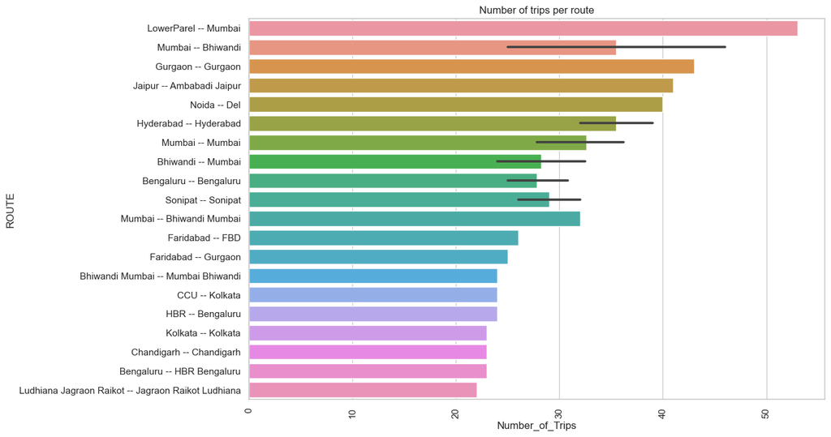

```python
plt.figure(figsize=(12,8))

X = route_records[["ROUTE", "Number_of_Trips",
               ]].sort_values(by="Number_of_Trips",ascending=False).head(35)
sns.barplot(y = X["ROUTE"],
           x= X["Number_of_Trips"])
plt.title("Number of trips per route")
plt.xticks(rotation = 90)
plt.show()
```

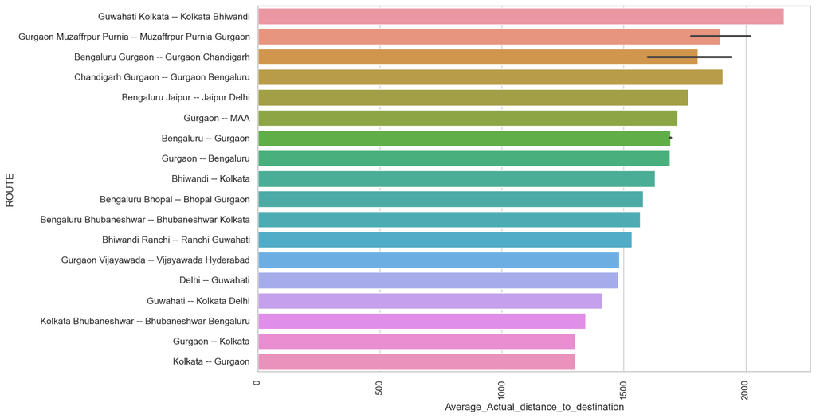

```python
plt.figure(figsize=(12,8))

X = route_records[["ROUTE", "Average_Actual_distance_to_destination",
               ]].sort_values(by="Average_Actual_distance_to_destination",ascending=False).head(25)
sns.barplot(y = X["ROUTE"],
           x = X["Average_Actual_distance_to_destination"])
plt.xticks(rotation = 90)
plt.show()
```

# Observations

- Based on the above bar chart and table, it's evident that the highest number of trips occurs within specific cities.
- Regarding the average distance between destinations, the longest routes are observed from Guwahati to Mumbai, Bengaluru to Chandigarh, Bengaluru to Delhi, and Bengaluru to Gurgaon.

### Finding the `busiest` and `longes`t routes

```python
Busiest_and_Longest_Routes  = route_records[(route_records["Average_Actual_distance_to_destination"] > route_records["Average_Actual_distance_to_destination"].quantile(0.75))
              & (route_records["Number_of_Trips"] > route_records["Number_of_Trips"].quantile(0.75))].sort_values(by="Average_Actual_distance_to_destination"
                                                                                                                  ,ascending=False)

Busiest_and_Longest_Routes_top25 = Busiest_and_Longest_Routes[["source_cities",
                                                               "destination_cities",
                                                               "Number_of_Trips",
                                                               "Average_Actual_distance_to_destination"]].head(25)
Busiest_and_Longest_Routes_top25.head()
```

|  | source_cities | destination_cities | Number_of_Trips | Average_Actual_distance_to_destination |
| --- | --- | --- | --- | --- |
| 629 | Chandigarh Gurgaon | Gurgaon Bengaluru | 22 | 1905.766051 |
| 995 | Gurgaon | Bengaluru | 21 | 1689.873158 |
| 991 | Gurgaon | Bengaluru | 21 | 1689.791894 |
| 512 | Bengaluru Bhubaneshwar | Bhubaneshwar Kolkata | 18 | 1567.577507 |
| 745 | Guwahati | Kolkata Delhi | 18 | 1411.208424 |

```python
Busiest_and_Longest_Routes_top25["Route"] = Busiest_and_Longest_Routes_top25["source_cities"].str.split(" ").apply(lambda x:x[0]) + " TO " + Busiest_and_Longest_Routes_top25["destination_cities"].str.split(" ").apply(lambda x:x[-1])
Busiest_and_Longest_Routes_top25.drop(["source_cities","destination_cities"],axis = 1,inplace=True)
```

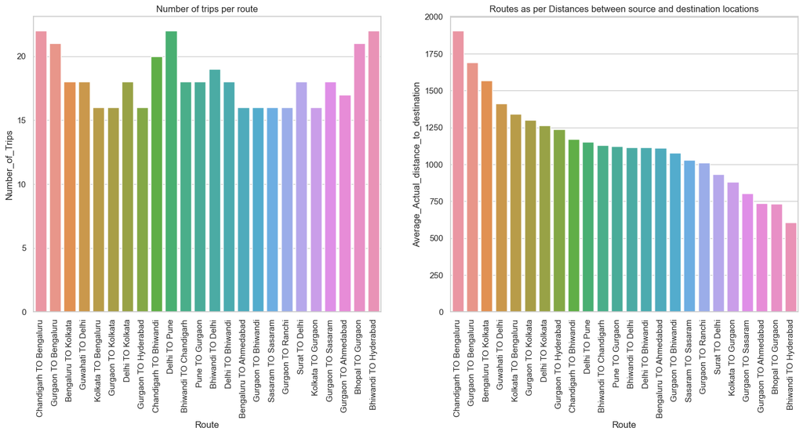

```python
plt.figure(figsize=(18,7))

plt.subplot(121)
plt.title("Number of trips per route")
sns.barplot(x=Busiest_and_Longest_Routes_top25["Route"],
           y = Busiest_and_Longest_Routes_top25["Number_of_Trips"])
plt.xticks(rotation = 90)
plt.subplot(122)
plt.title("Routes as per Distances between source and destination locations")
sns.barplot(x=Busiest_and_Longest_Routes_top25["Route"],
           y= Busiest_and_Longest_Routes_top25["Average_Actual_distance_to_destination"])
plt.xticks(rotation = 90)
plt.show()
```

### Routes which are passing through maxinum number of cities

```python
route_records[["SouceToDestination_city","Number_of_Trips",
               "Average_Actual_distance_to_destination",
               "#source_cities",
               "#destination_cities"]].sort_values(by=["#source_cities",
                                                       "#destination_cities",
                                                       "Number_of_Trips"]
                                                   ,ascending=False).head(25)
```

|  | SouceToDestination_city | Number_of_Trips | Average_Actual_distance_to_destination | #source_cities | #destination_cities |
| --- | --- | --- | --- | --- | --- |
| 0 | Guwahati TO LakhimpurN | 14 | 281.596486 | 13 | 11 |
| 2 | Jaipur TO Tarnau | 20 | 351.611796 | 10 | 10 |
| 1 | Guwahati TO Tura | 12 | 332.602225 | 10 | 10 |
| 3 | Mangalore TO Udupi | 9 | 195.257193 | 9 | 9 |
| 4 | Ajmer TO Raipur | 20 | 178.737233 | 9 | 8 |
| 5 | Mainpuri TO Tilhar | 12 | 207.247057 | 8 | 8 |
| 8 | Hassan TO Koppa | 21 | 200.497832 | 7 | 7 |
| 15 | Shrirampur TO Sangamner | 20 | 204.509529 | 7 | 7 |
| 7 | Musiri TO Tiruchi | 19 | 219.845121 | 7 | 7 |
| 9 | Bijnor TO Bijnor | 17 | 209.400685 | 7 | 7 |
| 10 | Dausa TO Lalsot | 17 | 232.408310 | 7 | 7 |
| 17 | Tinusukia TO Dibrugarh | 16 | 111.098543 | 7 | 7 |
| 12 | Pondicherry TO Pondicherry | 12 | 230.253602 | 7 | 7 |
| 14 | Mysore TO Mysore | 12 | 154.324190 | 7 | 7 |
| 6 | Golaghat TO Guwahati | 11 | 258.546587 | 7 | 7 |
| 13 | Varanasi TO Varanasi | 8 | 82.545019 | 7 | 7 |
| 16 | Vijayawada TO Suryapet | 8 | 407.029391 | 7 | 7 |
| 11 | Hyderabad TO Miryalguda | 7 | 420.603709 | 7 | 7 |
| 27 | Srikakulam TO Bobbili | 22 | 154.495283 | 6 | 6 |
| 36 | Pukhrayan TO Kanpur | 22 | 139.834945 | 6 | 6 |
| 48 | Dhule TO Shirpur | 22 | 150.016233 | 6 | 6 |
| 30 | Madhupur TO Madhupur | 21 | 252.072259 | 6 | 6 |
| 38 | Kamareddy TO Kamareddy | 21 | 177.923330 | 6 | 6 |
| 42 | Noida TO Khurja | 21 | 208.714043 | 6 | 6 |
| 20 | Junagadh TO Veraval | 19 | 179.538596 | 6 | 6 |

### Top 20 Longest Route as per, `average actual time` taken from one city to another city

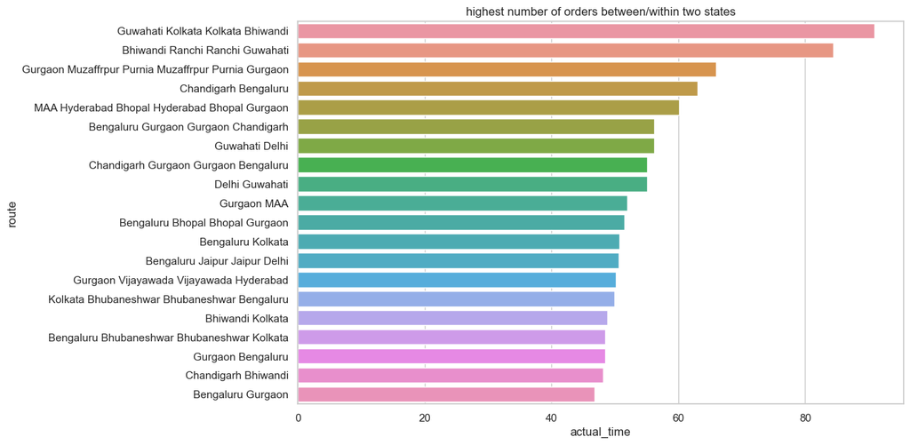

```python
Longest_route_as_per_actual_trip_time = trip_records.groupby(["source_city",
                      "destination_city"])["actual_time"].mean().sort_values(ascending=False).head(20).reset_index()
Longest_route_as_per_actual_trip_time["route"] = Longest_route_as_per_actual_trip_time["source_city"] + " " + Longest_route_as_per_actual_trip_time["destination_city"]
Longest_route_as_per_actual_trip_time.drop(["source_city",
                                            "destination_city"],axis = 1,inplace=True)
Longest_route_as_per_actual_trip_time
plt.figure(figsize=(11,7))
sns.barplot(y = Longest_route_as_per_actual_trip_time["route"],
           x = Longest_route_as_per_actual_trip_time["actual_time"],)
plt.title("highest number of orders between/within two states")
plt.show()
```

### Highest `number of trips` happening between/within two states

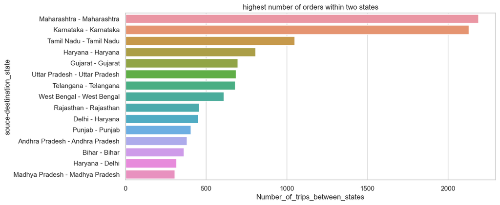

```python
highest_order_between_states = data.groupby(["source_state",
                                             "destination_state"])["trip_uuid"].nunique().sort_values(ascending=False).reset_index()

HOBS  = highest_order_between_states.head(15)
HOBS["souce-destination"] = HOBS["source_state"] + " - " + HOBS["destination_state"]
HOBS.drop(["source_state","destination_state"],axis = 1, inplace=True)
HOBS.columns = ["Number_of_trips_between_states","souce-destination_state"]

plt.figure(figsize=(11,5))
sns.barplot(y = HOBS["souce-destination_state"],
           x = HOBS["Number_of_trips_between_states"],)
plt.title("highest number of orders within two states")
plt.show()
```

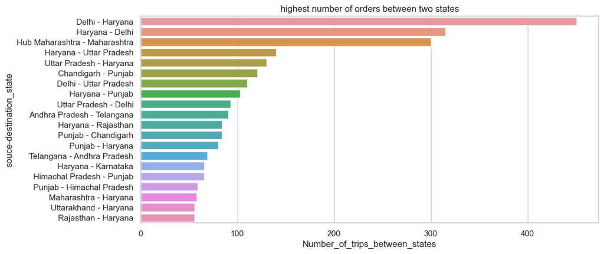

```python
HOBS = data.groupby(["source_state","destination_state"])["trip_uuid"].nunique().sort_values(ascending=False).reset_index()
HOBS = HOBS[HOBS["source_state"]!=HOBS["destination_state"]].head(20)

HOBS["souce-destination"] = HOBS["source_state"] + " - " + HOBS["destination_state"]
HOBS.drop(["source_state","destination_state"],axis = 1, inplace=True)
HOBS.columns = ["Number_of_trips_between_states","souce-destination_state"]

plt.figure(figsize=(11,5))
sns.barplot(y = HOBS["souce-destination_state"],
           x = HOBS["Number_of_trips_between_states"],)
plt.title("highest number of orders between two states")
plt.show()
```

# Observations

- Based on the above charts:
  - The route from Delhi to Haryana is the most frequented, with over 400 trips recorded. Other busy routes include Haryana to Uttar Pradesh, Chandigarh to Punjab, and Delhi to Uttar Pradesh.
  - Within certain states such as Maharashtra, Karnataka, and Tamil Nadu, the number of trips exceeds 1000.

### Top 10 `warehouses` with `heavy traffic`

```python
destination_traffic = data.groupby(["destination_city_state"])["trip_uuid"].nunique().reset_index()
source_traffic = data.groupby(["source_city_state"])["trip_uuid"].nunique().reset_index()
transactions = source_traffic.merge(destination_traffic,
                               left_on="source_city_state"
                               ,right_on="destination_city_state")
transactions.columns = ["source_city_state","#Trips_s","destination_city_state","#Trips_d"]
transactions["TripsTraffic"] = transactions["#Trips_s"]+transactions["#Trips_d"]
transactions.drop(["#Trips_s","#Trips_d","destination_city_state"],axis = 1,inplace=True)
transactions.columns = ["Warehouse_City(Junction)","TripsTraffic"]
```

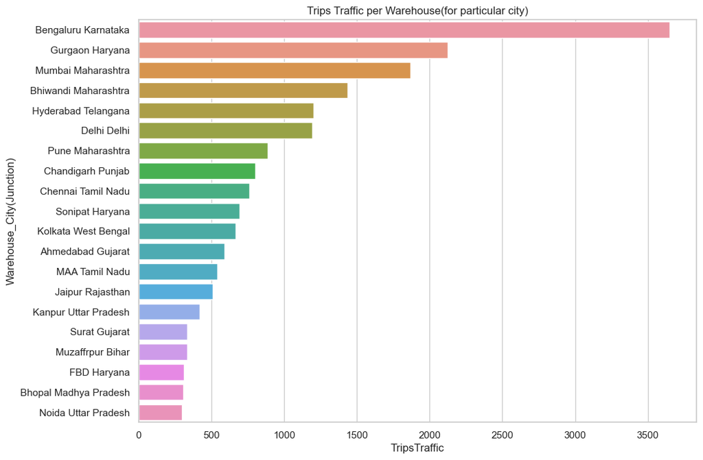

```python
T = transactions.sort_values(by=["TripsTraffic"],ascending=False).head(20)
plt.figure(figsize=(11,8))
sns.barplot(y = T["Warehouse_City(Junction)"],
           x = T["TripsTraffic"])
plt.title("Trips Traffic per Warehouse(for particular city)")
plt.show()
```

```python
trip_records.groupby(["source_state","destination_state"])["trip_uuid"].count().sort_values(ascending=False).head(15).reset_index()
```

|  | source_state | destination_state | trip_uuid |
| --- | --- | --- | --- |
| 0 | Maharashtra | Maharashtra | 2085 |
| 1 | Karnataka | Karnataka | 2002 |
| 2 | Tamil Nadu | Tamil Nadu | 996 |
| 3 | Haryana | Haryana | 771 |
| 4 | Telangana | Telangana | 627 |
| 5 | Gujarat | Gujarat | 624 |
| 6 | West Bengal | West Bengal | 610 |
| 7 | Uttar Pradesh | Uttar Pradesh | 529 |
| 8 | Rajasthan | Rajasthan | 400 |
| 9 | Delhi | Haryana | 385 |
| 10 | Andhra Pradesh | Andhra Pradesh | 344 |
| 11 | Punjab | Punjab | 342 |
| 12 | Bihar | Bihar | 330 |
| 13 | Haryana | Delhi | 307 |
| 14 | Hub Maharashtra | Maharashtra | 300 |

# Observations

- The list below showcases the top 20 busiest warehouses (junctions) based on the trip traffic at each junction:
  - Bengaluru, Karnataka
  - Gurgaon, Haryana
  - Mumbai, Maharashtra
  - Bhiwandi, Maharashtra
  - Hyderabad, Telangana
  - Delhi, Delhi
  - Pune, Maharashtra
  - Chandigarh, Punjab
  - Chennai, Tamil Nadu
  - Sonipat, Haryana
  - Kolkata, West Bengal
  - Ahmedabad, Gujarat
  - MAA, Tamil Nadu
  - Jaipur, Rajasthan
  - Kanpur, Uttar Pradesh
  - Surat, Gujarat
  - Muzaffarpur, Bihar
  - FBD, Haryana
  - Bhopal, Madhya Pradesh
  - Noida, Uttar Pradesh